# Wage Distributions and the Bite of Minimum Wages Across Philippine Regions

National Analysis Using Harmonized LFS Microdata, 2004–2025 — v5 (Companion to the NCR Proof of Concept)

AJ Montesa

July 24, 2026

# 1 Overview

This document extends the **NCR proof of concept** (`ncr_mw_proof_of_concept_v5.Rmd`) to a **national, all-region analysis** of Philippine wage distributions and the bite of regional minimum wages, using the v8 harmonized LFS microdata (2004 Q1 – 2025 Q2, 86 quarterly rounds). It is the third document in the minimum-wage series:

1. *Minimum Wages and Inflation* — real erosion of regional wage orders.
2. *Minimum Wages and Productivity* — wage floors vs. labour productivity.
3. **This document** — where the wage floor sits inside the observed wage distribution, region by region.

Following Cengiz, Dube, Lindner & Zipperer (2019), we keep four concepts separate: **statutory bindingness** (Kaitz index, share at/below the floor), **observed bunching** (mass near the floor), **noncompliance** (mass strictly below the floor, with the coverage caveats that phrase requires), and **causal employment effects**. This document delivers the first three descriptively at national scale, adds a **descriptive stacked event-study approximation** of the Cengiz bunching design around wage-order increases (N14), and produces — as saved artifacts — the region × quarter × wage-bin panels (nominal MW-relative, N8, and spatially-indexed real-peso, N13) that any future causal stacked-DiD analysis would consume. It deliberately does **not** attempt causal estimation: the event study is a before/after description with an internal pre-trend check, no more.

## 1.1 Headline conventions (changes relative to the NCR PoC)

These were agreed in the design discussion; each is implemented and cross-checked below, and the Reconciliation section reconciles NCR numbers under old vs. new conventions.

[output not shown]

## 1.2 Reading guide for units and bands

Different statistics live on different scales, deliberately:

- **Scale-free statistics** (Kaitz index, share below MW, ±5% at-band, log-distance bunching histograms): computed on **nominal** wages against the **nominal** contemporaneous MW. Because both sides are deflated by the same regional CPI, deflation cancels; nominal and real give identical numbers for these ratios.
- **Cross-year absolute comparisons** (wage *levels*, distribution snapshots, poverty-wage overlays): **real 2018 PHP**, deflated by the **regional** CPI.
- **Wage-bin objects** (the ₱25-bin panels in the wage-bin section): two complementary scales. The **nominal** panel bins $(w - MW)$ in contemporaneous pesos (the raw Cengiz unit). The **spatially-indexed real** panel (N13) bins $(w^{real} - MW^{real})/\theta_r$ in NCR-2018-equivalent pesos — CPI indexes time, the 2018 poverty-threshold ratios index place — which is the unit in which bins can be summed nationally and events averaged across regions.

# 2 Notation and Formulas

Every statistic below is defined here **before** any code computes it. Each computing chunk restates, in comments, the formula it implements, so the code can be audited line-by-line against this section.

**Indexing.** $i$ indexes person-quarter observations; $r$ indexes wage-board lineages (lineage recode section); $t$ indexes LFS rounds, anchored at reference date $d_t$ = the first day of the survey reference month (Jan 1 / Apr 1 / Jul 1 / Oct 1); $m(d)$ = the calendar month containing date $d$. $w_i$ is reported **daily basic pay** (`basic_pay_php`, already daily-equivalent in the PUF); $\omega_i$ is the LFS sampling weight (`weight`).

**(N1) Weighted empirical CDF and quantiles.** For a set $S$ of observations,
$$\hat F_S(x) \;=\; \frac{\sum_{i \in S}
\omega_i\,\mathbf 1[w_i \le x]}{\sum_{i \in S} \omega_i},
\qquad
Q_S(p) \;=\; \min\{\,x \in \{w_i\}_{i\in S} : \hat F_S(x) \ge
p\,\}.$$
$Q_S(p)$ is the left-continuous inverse (a step function taking observed values only). This matches the `weighted_quantile()` helper exactly — no interpolation between order statistics.

**(N2) As-of minimum-wage assignment.** Let $E_r = \{e_1 < e_2 < \dots\}$ be the effectivity dates of lineage $r$’s wage-order rows (each tranche is its own row). For any date $d$:
$$MW_r(d)
\;=\; \text{rate of the row with effectivity } \max\{e \in E_r : e \le
d\}.$$
Applied to each of the four rate columns, giving $MW^{tot,max}_r(d),\; MW^{tot,min}_r(d),\; MW^{bas,max}_r(d),\; MW^{bas,min}_r(d)$. The **headline threshold** is $MW^{tot,max}$ (highest non-agriculture total rate — the doc-1 convention); $MW^{tot,min}$ bounds the analysis from below (N5). Because $d_t$ is the *first* day of the reference month, a wage order effective mid-month is assigned only from the *following* round — the same anchoring convention as the NCR PoC (its WO-25 note).

**(N3) Regional CPI deflator.** Let $CPI_{r,m}$ be the all-items index for lineage $r$ in month $m$ from the pre-NIR workbook (chained across base periods by PSA; continuity verified at each sheet junction below). Define the region base $\overline{CPI}_r^{2018} = \tfrac{1}{12}\sum_{m \in 2018} CPI_{r,m}$ and
$$w^{real}_i
\;=\; w_i \times
\frac{\overline{CPI}_r^{2018}}{CPI_{r,\,m(d_t)}}.$$
If the workbook is exactly 2018-based, $\overline{CPI}_r^{2018} = 100$ and this reduces to $w_i \times 100 / CPI_{r,m}$; the rebasing step makes that an identity we *verify* rather than assume.

**(N4) Bindingness statistics** (computed on Sample C, per $r,t$ cell, against $MW = MW^{tot,max}_r(d_t)$ unless stated):

- Kaitz (median): $\;K^{med}_{r,t} = MW / Q_{r,t}(0.5)$; Kaitz (mean): $K^{mean}_{r,t} = MW / \bar w_{r,t}$ with $\bar w_{r,t} = \sum \omega_i w_i / \sum \omega_i$.
- Share at-or-below: $\;F_{r,t}(MW) = \hat F_{r,t}(MW)$ (weak inequality).
- Strict noncompliance share: $\;B_{r,t} = \sum \omega_i \mathbf 1[w_i < MW] / \sum \omega_i$.

**(N5) The min–max noncompliance interval.** With multiple rates inside a region, one collapsed threshold cannot classify every worker correctly. We bound:
$$B^{min}_{r,t} = \Pr_\omega\!\big[w_i <
MW^{tot,min}\big]
\;\le\; \text{true noncompliance} \;\le\;
B^{max}_{r,t} = \Pr_\omega\!\big[w_i < MW^{tot,max}\big].$$
$B^{min}$ counts only workers below *every* applicable rate (definite subminimum pay); $B^{max}$ adds workers between the lowest and highest rate, whose status depends on unobserved sub-regional/establishment coverage. Charts draw the ribbon between the two.

**(N6) Compliance partition (±5% band).** With $\rho_i = w_i / MW - 1$:
$$\text{below: } \rho_i < -0.05; \qquad
\text{at: } |\rho_i| \le 0.05; \qquad
\text{above: } \rho_i > 0.05.$$
The three weighted shares partition Sample C exactly (each observation in exactly one class). Note “below” here is $w_i < 0.95\,MW$ — a *band* boundary — and is therefore **not** the same object as the strict noncompliance share $B_{r,t}$ in (N4); both are reported. Sensitivity band: $|w^{real}_i - MW^{real}| \le 25\,\theta_r$ in 2018 PHP — the PoC’s real-₱25 band, spatially indexed per (N13) so its purchasing-power width is the same in every region (in NCR, $\theta = 1$, it is exactly the PoC band).

**(N7) Log-distance bunching histogram.** For bin width $h = 0.025$ log points and bin index $k$, the weighted share in bin $k$ is
$$s_k =
\frac{\sum_i \omega_i\,\mathbf 1\big[\,k h \le \log w_i - \log
MW_{r(i)}(d_{t(i)}) < (k+1)h\,\big]}{\sum_i \omega_i},$$
pooled over all region-quarters (each worker measured against their *own* contemporaneous regional floor).

**(N8) ₱25 wage-bin panel.** Bin edges $b \in \{-300, -275, \dots, 600\}$ (left-closed): observation $i$ falls in bin $b$ if $b \le w_i - MW^{tot,max}_{r}(d_t) < b + 25$ (nominal pesos). The panel records, per $(r, t, b)$: unweighted count, summed weight, and weighted share of the $(r,t)$ cell. Saved to `Output/` in the wage-bin section.

**(N9) Poverty-threshold daily-wage equivalent.** From the PSA **annual per-capita** threshold $PT^{pc}_{r,y}$ (survey years $y$):
$$PT^{wage}_{r,y} \;=\; PT^{pc}_{r,y} \times
\frac{\text{FAMILY\_SIZE}}{\text{EARNERS} \times \text{FACTOR\_DAYS}}
\;=\; PT^{pc}_{r,y} \times \frac{5}{1 \times 313},$$
the daily basic wage at which one earner, paid every DOLE factor day (365 − 52 rest days = 313), keeps a family of five exactly at the poverty line. All three constants are setup parameters; the ÷365 calendar-day variant is shown as an alternative in the poverty-benchmark section.

**(N10) Monthly projection of the threshold (headline: CPI projection).** With $y^*(m) = \max\{y \in Y_r : y \le \text{year}(m)\}$ (latest survey year not after $m$) and $\overline{CPI}_{r,y}$ = the mean of monthly CPI over calendar year $y$:
$$PT^{wage}_{r,m} \;=\; PT^{wage}_{r,y^*}
\times \frac{CPI_{r,m}}{\overline{CPI}_{r,y^*}}.$$
This holds the threshold constant in *real* terms between survey years — the same logic PSA uses for inter-FIES updates — and extrapolates 2024–2025 from the 2023 base. **Sensitivity:** linear interpolation in nominal levels between survey-year anchors placed at July 1 of each survey year, with no extrapolation beyond the last anchor. The poverty-threshold preparation section overlays the two.

**(N11) Aggregation to the national level.** Shares and histogram statistics aggregate by **person-level pooling against each worker’s own regional floor** — e.g. the national strict-noncompliance share is
$$B^{nat}_t =
\frac{\sum_{i \in t} \omega_i\,\mathbf 1[w_i <
MW_{r(i)}(d_t)]}{\sum_{i \in t} \omega_i},$$
*not* a comparison to any national rate (none exists). The Kaitz index has no national statutory referent, so the “national” Kaitz is reported as the covered-employment-weighted mean of regional indices, $K^{nat}_t = \sum_r \Omega_{r,t} K_{r,t} / \sum_r \Omega_{r,t}$ with $\Omega_{r,t} = \sum_{i \in r,t} \omega_i$, drawn with the cross-region min–max range shaded.

**(N12) Heaping shares.** For divisor $d \in \{5, 10, 50, 100\}$: $H_d = \Pr_\omega[\,w_i \bmod d = 0\,]$ (weighted share of wage reports exactly divisible by $d$).

**(N13) Spatial price index and comparable real-peso bands.** The regional CPI (N3) indexes prices over **time within a region** but says nothing about price-**level** differences **across regions**: a real 2018 ₱25 in NCR is not the same purchasing power as a real 2018 ₱25 in BARMM, so the NCR PoC’s ±₱25 band does not transfer to a national analysis unmodified. The regional poverty thresholds *are* priced at local costs, so their cross-region ratios provide the missing spatial deflator. Define, from the 2018 (No-NIR vintage) **per-capita** thresholds,
$$\theta_r \;=\;
\frac{PT^{pc}_{r,2018}}{PT^{pc}_{NCR,2018}}, \qquad \theta_{NCR} =
1,$$
(the family-size / earner / factor-day constants of N9 cancel in the ratio, so $\theta_r$ does not depend on the poverty-*wage* construct). The **spatially-and-temporally adjusted** wage and floor are
$$\tilde w_i =
\frac{w^{real}_i}{\theta_{r(i)}}, \qquad
\tilde M_{r,t} =
\frac{MW^{tot,max}_{r}(d_t)/\text{defl}_{r,m}}{\theta_r},$$
both in **NCR-2018-equivalent pesos**. A ±₱25 band on this scale is the *same real band everywhere*: in region $r$’s own 2018 pesos it has width $25\,\theta_r$, scaled to local price levels. Real wage bins are then left-closed ₱25 bins of $\tilde w_i - \tilde M_{r,t}$ — distance from the **real minimum wage** — over $\{-300, \dots, 600\}$; because every term is in one common unit, bin masses are summable across regions and years, and in NCR ($\theta = 1$) the construction reduces exactly to the PoC’s.

**(N14) Wage-increase event study (Cengiz-style, stacked, with timing-based controls).** An **event** $e = (r, t_0)$ is the first LFS round at which the as-of assignment (N2) delivers a new, higher $MW^{tot,max}$ with nominal size $\Delta_e = MW^{new}/MW^{old} - 1 \ge 3\%$. Event time $\tau = t - t_0$ spans $[-4, +7]$ (pre-window $[-4,-1]$, matching the PoC), post-side censored at the lineage’s next event. The event’s floor is fixed in NCR-2018-equivalent pesos (N13): $\tilde M_e = MW^{new}_r(t_0) / (\text{defl}_{r,m(t_0)}\,\theta_r)$. For real ₱25 bins $b$ of $\tilde w_i - \tilde M_e$ over $[-300, 600)$, the outcome is **bin employment per working-age person** (per-capita counts, not shares — shares can only show redistribution, never employment loss):
$$E_{e,\tau,b} = \frac{\sum_{i \in
C_{r,t_0+\tau},\,b} \omega_i}{\text{WAP}_{r,\,t_0+\tau}},
\qquad \Delta E_{e,\tau,b} = E_{e,\tau,b} -
\tfrac{1}{4}\textstyle\sum_{\tau'=-4}^{-1}
E_{e,\tau',b}.$$
**Controls.** For each event, control lineages are those with **no own event within $[t_0-4,\,t_0+4]$**; their bins are measured against the *treated* event’s $\tilde M_e$ — meaningful only because N13 puts all regions on one real-peso scale. The DiD contrast is $\Delta E^{DiD}_{e,\tau,b} = \Delta E^{treat}_{e,\tau,b} - \overline{\Delta E}^{ctrl}_{e,\tau,b}$ (equal-weighted control mean), reported for events with ≥ 3 controls. **Summary statistics** (post = mean over $\tau \in [0,3]$, equal-weighted across events), following the PoC’s grid: missing mass $\Delta b = \sum_{b<0} \Delta E$; excess mass $\Delta a(B^*) = \sum_{0 \le b < B^*} \Delta E$ for $B^* \in \{100, 200, 300\}$; net low-wage change $\Delta b + \Delta a(B^*)$; bunching ratio $\Delta a / |\Delta b|$; and the **upper-tail placebo** $\sum_{300 \le b < 600} \Delta E$, which should be ≈ 0 if changes are localised at the floor. Uncertainty: percentile confidence intervals from a nonparametric bootstrap over **events** (resampling whole events, 500 draws). **Identification caveat:** the control set is selected on wage-order *timing*, not random assignment; no never-treated region exists, and control availability is concentrated in freeze episodes (2009–10, 2020–21). This is the closest feasible approximation to Cengiz et al., not a replication of their identification.

# 3 Setup

```r
library(tidyverse)
library(lubridate)
library(scales)
library(readxl)
library(knitr)

# kableExtra is used for table styling when available; the document knits
# without it (plain kable) so the pipeline has no hard dependency on it.
HAS_KE <- requireNamespace("kableExtra", quietly = TRUE)
if (HAS_KE) library(kableExtra)

theme_set(theme_minimal(base_size = 12))

# ---- Helpers ---------------------------------------------------------------

# (N1) Weighted quantile: left-continuous inverse of the weighted ECDF.
# Q(p) = min{ x in observed values : Fhat(x) >= p }. No interpolation.
weighted_quantile <- function(x, w, probs) {
  if (length(x) == 0 || all(is.na(x))) return(rep(NA_real_, length(probs)))
  keep <- !is.na(x) & !is.na(w) & w > 0
  x <- x[keep]; w <- w[keep]
  if (length(x) == 0) return(rep(NA_real_, length(probs)))
  ord <- order(x); x <- x[ord]; w <- w[ord]
  cumw <- cumsum(w) / sum(w)
  vapply(probs, function(p) x[which(cumw >= p)[1]], numeric(1))
}

# Weighted mean (explicit, NA-safe)
wmean <- function(x, w) {
  keep <- !is.na(x) & !is.na(w)
  if (!any(keep)) return(NA_real_)
  sum(x[keep] * w[keep]) / sum(w[keep])
}

# Weighted share of a logical condition
wshare <- function(cond, w) wmean(as.numeric(cond), w)

# Styled table wrapper (falls back to plain kable without kableExtra)
kt <- function(df, cap, digits = getOption("digits"), ...) {
  k <- kable(df, caption = cap, digits = digits, ...)
  if (HAS_KE) {
    k %>% kable_styling(bootstrap_options = c("striped", "hover", "condensed"),
                        full_width = FALSE, font_size = 13)
  } else k
}

wrap_text <- function(x, width = 95) paste(strwrap(x, width = width), collapse = "\n")

# ---- Project constants -----------------------------------------------------

# Fixed wage-board lineage order used in EVERY faceted chart and table.
REGION_ORDER <- c("NCR", "CAR", "I", "II", "III", "IV-A", "IV-B", "V",
                  "VI", "VII", "VIII", "IX", "X", "XI", "XII", "XIII",
                  "ARMM-BARMM")

# (N6) headline at-MW band: +/- 5% of the applicable MW
AT_MW_BAND_PCT   <- 0.05
# sensitivity band: +/- 25 real 2018 PHP (NCR PoC convention)
AT_MW_BAND_PHP_REAL <- 25
BASE_YEAR        <- 2018L

# (N8) wage-bin construction (nominal PHP relative to MW^{tot,max})
BIN_PHP    <- 25
BIN_LO     <- -300
BIN_HI     <- 600

# (N7) log-distance histogram bin width (log points)
LOG_BIN_H  <- 0.025
LOG_BIN_LIM <- 0.70

# (N13) spatially comparable real bins: P25 width in NCR-2018-equivalent
# pesos, relative to the REAL minimum wage; theta_r built at run time from
# the 2018 poverty thresholds
SPATIAL_BASE <- "NCR"       # numeraire lineage for theta (theta_NCR = 1)
BIN_REAL_LO <- -300
BIN_REAL_HI <- 600

# (N14) wage-increase event study (Cengiz-style)
EVENT_MIN_NOM_PCT <- 0.03   # prominence screen: nominal increase >= 3%
EVENT_PRE_Q       <- 4      # pre-window: tau in [-4, -1] (PoC convention)
EVENT_POST_Q      <- 7      # max post-window: tau in [0, +7], censored at
                            # the next event in the same lineage
EVENT_BIN_LO      <- -300   # event bins: NCR-2018-equivalent pesos
EVENT_BIN_HI      <-  600   # relative to the NEW real floor, P25 width
EXCESS_GRID       <- c(100, 200, 300)  # B* grid for excess mass (PoC)
PLACEBO_LO        <- 300    # upper-tail placebo zone: [300, 600)
MIN_CONTROLS      <- 3      # events need >= this many clean controls (DiD)
N_BOOT            <- 500    # bootstrap draws over events
set.seed(20260724)

# (N9) poverty-wage conversion parameters
FAMILY_SIZE <- 5
EARNERS     <- 1
FACTOR_DAYS <- 313      # 365 - 52 rest days (DOLE factor-day convention)
FACTOR_DAYS_ALT <- 365  # calendar-day variant shown in the poverty-benchmark section

# Percentile grid
PCTL_GRID <- c(0.05, 0.10, 0.25, 0.50, 0.75, 0.90, 0.95)

# Sample-C definition (see Sample Construction)
COVERED_CLASS <- "Private Establishment"
WAGE_CLASS_LABELS <- c("Private Establishment", "Government/GOCC",
                       "Private Household")

MIN_CELL_N <- params$min_cell_n
```

# 4 Data Preparation

## 4.1 Load harmonized LFS and assert the required schema

Rather than auto-detecting columns, this document **asserts** the exact columns it needs and stops with a diagnostic if any is missing — a schema mismatch should fail at the top, not corrupt charts downstream.

```r
lfs_raw <- read_rds(params$lfs_path)

required_cols <- c("year", "quarter", "month", "region", "province",
                   "weight", "male", "age_years", "educ_5cat",
                   "class_label", "ind_section", "payment_label",
                   "basic_pay_php", "employed")
missing_cols <- setdiff(required_cols, names(lfs_raw))
if (length(missing_cols) > 0) {
  stop("LFS file is missing required columns: ",
       paste(missing_cols, collapse = ", "),
       "\nColumns present: ", paste(sort(names(lfs_raw)), collapse = ", "))
}

cat("Rows:", comma(nrow(lfs_raw)), "  Cols:", ncol(lfs_raw), "\n")
```

```
## Rows: 18,825,641   Cols: 75
```

```r
cat("Years:", paste(range(lfs_raw$year, na.rm = TRUE), collapse = "-"), "\n")
```

```
## Years: 2004-2025
```

## 4.2 Wage-board lineage recode (`region_wb`)

The raw LFS `region` codes migrate over the sample, as established from the weighted-population tabulation (`LFS_-_Region.xlsx`):

- `41`/`42` = IV-A / IV-B through 2016 Q1; `4`/`17` from 2016 Q2 onward.
- `15` = ARMM through 2023 Q3; `19` = BARMM from 2023 Q4. One wage-board lineage (`ARMM-BARMM`).
- `18` = **NIR**, present only in 2016 Q4 and 2025 Q1–Q2. There is no NIR wage board in the wage-order panel, so NIR observations are mapped back to the VI / VII lineages **via province** (45 = Negros Occidental → VI; 46 = Negros Oriental, 61 = Siquijor → VII), mirroring the harmonization script’s `region_standard` construction. NIR rows with *missing* province cannot be assigned and are excluded with an explicit count below.
- All other codes map one-to-one (13 = NCR, 14 = CAR, 16 = XIII/Caraga, 1–12 = Regions I–XII).

Note this recode is built from the **raw** `region` variable, not `region_standard`: the v8 documentation states `region_standard` spans 1–17, but the raw codes demonstrably include 41/42 pre-2016 Q2, and `region_standard` passes non-Negros codes through unchanged — so it would carry 41/42 in early years. Building the lineage here, from raw codes, with a full validation crosstab, removes that ambiguity.

```r
# The raw codes in the harmonized file are ZERO-PADDED STRINGS ("01".."19",
# "41", "42"). All matching is therefore done on the INTEGER value of the
# code, which is invariant to padding ("01", "1", and numeric 1 all map
# identically). The mapping is UNCONDITIONAL on date because no integer code
# is reused with a different meaning: 4/17 do not occur before 2016 Q2,
# 41/42 do not occur after 2016 Q1, 19 does not occur before 2023 Q4. The
# crosstab below verifies this empirically on the loaded file.
lfs <- lfs_raw %>%
  mutate(
    region_chr   = str_trim(as.character(region)),
    region_int   = suppressWarnings(as.integer(region_chr)),
    province_int = suppressWarnings(as.integer(str_trim(as.character(province)))),
    region_wb = case_when(
      region_int == 13L ~ "NCR",
      region_int == 14L ~ "CAR",
      region_int == 1L  ~ "I",
      region_int == 2L  ~ "II",
      region_int == 3L  ~ "III",
      region_int %in% c(41L, 4L)  ~ "IV-A",
      region_int %in% c(42L, 17L) ~ "IV-B",
      region_int == 5L  ~ "V",
      region_int == 6L  ~ "VI",
      region_int == 7L  ~ "VII",
      region_int == 8L  ~ "VIII",
      region_int == 9L  ~ "IX",
      region_int == 10L ~ "X",
      region_int == 11L ~ "XI",
      region_int == 12L ~ "XII",
      region_int == 16L ~ "XIII",
      region_int %in% c(15L, 19L) ~ "ARMM-BARMM",
      # NIR: assign by province; NA province -> NA (excluded, counted below)
      region_int == 18L & province_int == 45L              ~ "VI",
      region_int == 18L & province_int %in% c(46L, 61L)    ~ "VII",
      TRUE ~ NA_character_
    ),
    region_wb = factor(region_wb, levels = REGION_ORDER),
    # LFS reference date: first day of the survey reference month (N2 anchor)
    ref_date  = make_date(year, month, 1L)
  )
```

### 4.2.1 Validation: raw-code × period crosstab and unmapped rows

```r
# Every raw code should appear only in its expected era, and every row
# should map to a lineage except NIR-with-missing-province.
code_era <- lfs %>%
  mutate(era = case_when(
    year < 2016 | (year == 2016 & quarter == 1) ~ "2004Q1-2016Q1",
    year < 2023 | (year == 2023 & quarter <= 3) ~ "2016Q2-2023Q3",
    TRUE                                        ~ "2023Q4-2025Q2"
  )) %>%
  count(era, region_int) %>%
  pivot_wider(names_from = era, values_from = n, values_fill = 0L) %>%
  arrange(region_int)

kt(code_era, "Raw region codes (integer value) by era, row counts. Expect 41/42 only in the first era, 4/17 only after, 15 only through 2023 Q3, 19 only after, 18 only in NIR quarters.")
```

Raw region codes (integer value) by era, row counts. Expect 41/42 only in the first era, 4/17 only after, 15 only through 2023 Q3, 19 only after, 18 only in NIR quarters.

| region_int | 2004Q1-2016Q1 | 2016Q2-2023Q3 | 2023Q4-2025Q2 |
| --- | --- | --- | --- |
| 1 | 553077 | 254924 | 62042 |
| 2 | 463603 | 272385 | 67470 |
| 3 | 798729 | 566620 | 139430 |
| 4 | 0 | 355966 | 87477 |
| 5 | 593134 | 398175 | 96481 |
| 6 | 673412 | 468215 | 108359 |
| 7 | 657618 | 394370 | 95010 |
| 8 | 501705 | 450545 | 110114 |
| 9 | 414254 | 291430 | 71826 |
| 10 | 457749 | 423008 | 105476 |
| 11 | 544343 | 369464 | 92694 |
| 12 | 507978 | 348927 | 75652 |
| 13 | 1086845 | 971930 | 228603 |
| 14 | 416044 | 394249 | 93107 |
| 15 | 500606 | 408326 | 0 |
| 16 | 435552 | 363639 | 88652 |
| 17 | 0 | 360846 | 91039 |
| 18 | 0 | 4593 | 10499 |
| 19 | 0 | 0 | 130019 |
| 41 | 974330 | 0 | 0 |
| 42 | 395100 | 0 | 0 |

```r
# Unmapped rows: total plus a compact by-year summary (always rendered; the
# table is empty when nothing is unmapped). Expected content: only code 18
# (NIR) with missing province.
unmapped_summary <- lfs %>%
  filter(is.na(region_wb)) %>%
  count(year, region_int, name = "n_unmapped")

cat("Unmapped rows (should be only NIR code 18 with missing province):",
    comma(sum(unmapped_summary$n_unmapped)), "of", comma(nrow(lfs)),
    sprintf("(%.3f%%)\n", 100 * sum(unmapped_summary$n_unmapped) / nrow(lfs)))
```

```
## Unmapped rows (should be only NIR code 18 with missing province): 8,063 of 18,825,641 (0.043%)
```

```r
kt(head(unmapped_summary, 12),
   "Unmapped rows by year and raw code, first 12 rows (empty table = full mapping; expected content: code 18 with missing province only)")
```

Unmapped rows by year and raw code, first 12 rows (empty table = full mapping; expected content: code 18 with missing province only)

| year | region_int | n_unmapped |
| --- | --- | --- |
| 2025 | 18 | 8063 |

```r
# HARD FAILURE on recode breakdown: anything beyond the NIR-missing-province
# sliver means the code mapping does not match this file's coding scheme
# (the v1 run lost 47.6% of rows to a zero-padding mismatch and still knit;
# this assertion makes that class of error fatal at the source).
unmapped_share <- sum(unmapped_summary$n_unmapped) / nrow(lfs)
if (unmapped_share > 0.005) {
  stop(sprintf(paste0(
    "Region recode failed: %.1f%% of rows unmapped (tolerance 0.5%%). ",
    "Inspect the raw-code crosstab above and update the region_wb mapping."),
    100 * unmapped_share))
}

lfs <- lfs %>% filter(!is.na(region_wb))
```

### 4.2.2 Validation: lineage × quarter coverage grid

Two known data events should be visible here rather than discovered later: the **Region VIII Yolanda gap** (absent 2014 Q1; reduced enumeration through 2015 Q2) and any low-N region-quarters (flag threshold: 30 covered-sample observations, applied again at sample construction).

```r
coverage <- lfs %>%
  count(region_wb, year, quarter, name = "n_all") %>%
  complete(region_wb, nesting(year, quarter), fill = list(n_all = 0L))

missing_cells <- coverage %>% filter(n_all == 0)
cat("Lineage-quarters with ZERO LFS observations:", nrow(missing_cells),
    "(expected: Region VIII in 2014 Q1; anything else needs investigation)\n")
```

```
## Lineage-quarters with ZERO LFS observations: 1 (expected: Region VIII in 2014 Q1; anything else needs investigation)
```

```r
kt(head(missing_cells, 20),
   sprintf("Zero-observation lineage-quarters (first %d of %d shown)",
           min(20, nrow(missing_cells)), nrow(missing_cells)))
```

Zero-observation lineage-quarters (first 1 of 1 shown)

| region_wb | year | quarter | n_all |
| --- | --- | --- | --- |
| VIII | 2014 | 1 | 0 |

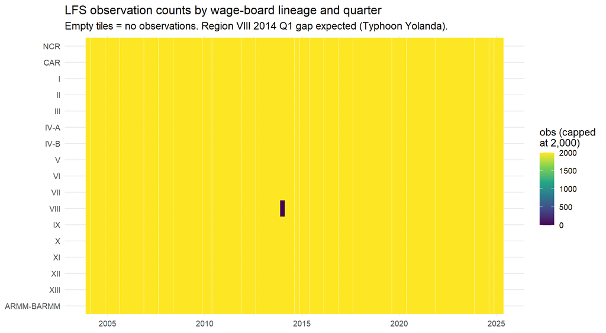

```r
coverage %>%
  mutate(ref_date = make_date(year, c(1, 4, 7, 10)[quarter], 1)) %>%
  ggplot(aes(ref_date, fct_rev(region_wb), fill = pmin(n_all, 2000))) +
  geom_tile() +
  scale_fill_viridis_c(name = "obs (capped\nat 2,000)") +
  labs(title = "LFS observation counts by wage-board lineage and quarter",
       subtitle = "Empty tiles = no observations. Region VIII 2014 Q1 gap expected (Typhoon Yolanda).",
       x = NULL, y = NULL)
```

## 4.3 Wage orders: load, lineage mapping, and as-of assignment

Lineage mapping on the wage-order side:

- `ARMM` and `BARMM` rows are concatenated into the single `ARMM-BARMM` lineage (BARMM legally succeeded ARMM’s wage board).
- Pre-split `IV` rows (all pre-2002) are **duplicated into both** `IV-A` and `IV-B` lineages, so that an as-of lookup early in a lineage’s life still finds the inherited Region IV rate. This affects no 2004+ assignment in practice (both boards issued post-split orders before 2004) but makes the join total rather than partial.

```r
mw_raw <- read_csv(params$mw_path, show_col_types = FALSE)

# CHECK-flagged rows: surfaced, used as-is (doc-1 convention). The display
# is capped; the count line is the audit trail.
mw_check <- mw_raw %>%
  filter(str_detect(coalesce(notes, ""), "CHECK")) %>%
  select(region, wage_order, effectivity_date, total_min, total_max, notes)
cat("CHECK-flagged wage-order rows (used as-is):", nrow(mw_check),
    "of", nrow(mw_raw), "\n")
```

```
## CHECK-flagged wage-order rows (used as-is): 34 of 554
```

```r
kt(head(mw_check, 10),
   sprintf("First %d of %d CHECK-flagged wage-order rows (used as-is, doc-1 convention)",
           min(10, nrow(mw_check)), nrow(mw_check)))
```

First 10 of 34 CHECK-flagged wage-order rows (used as-is, doc-1 convention)

| region | wage_order | effectivity_date | total_min | total_max | notes |
| --- | --- | --- | --- | --- | --- |
| NCR | WO 12 | 2006-07-11 | 313 | 350.0 | CHECK: total implies basic 263-300; source basic_min 288 likely typo |
| NCR | WO 27 | 2026-07-25 | 718 | 755.0 | CHECK: source shows date issued 23-Jun-25; likely 23-Jun-26 |
| I | WO 08 | 2000-12-15 | 150 | 190.0 | CHECK: basic_min drops vs WO 07; likely rate restructuring by area class |
| I | WO 16 | 2014-02-05 | 213 | 253.0 | CHECK: basic_min drops vs WO 15; likely restructuring |
| III | WO 10 | 2004-08-20 | 197 | 243.5 | CHECK: basic_min drops vs WO 09; likely restructuring |
| III | WO 11 | 2005-08-19 | 217 | 263.5 | Under WO 10; COLA partially integrated; total unchanged; CHECK: total implies basic_max 243.50; source prints 248.50 |
| IV-A | WO IVA-15 | 2012-05-15 | 255 | 349.5 | CHECK: COLA applies to select areas; total_min shown without COLA in source |
| IV-A | WO IVA-16 | 2014-05-01 | 261 | 362.5 | CHECK: source shows allowance as 12.50+13.00; totals as printed |
| IV-A | WO IVA-17 | 2016-07-01 | 285 | 378.5 | CHECK: total_min shown without COLA in source |
| IV-B | WO IV-B-06 | 2013-02-01 | 205 | 275.0 | CHECK: basic_min drops vs WO IV-B-05; likely restructuring |

```r
mw_lineage <- mw_raw %>%
  mutate(effectivity_date = as.Date(effectivity_date)) %>%
  filter(!is.na(effectivity_date)) %>%
  # region -> lineage
  mutate(region_wb = case_when(
    region %in% c("ARMM", "BARMM") ~ "ARMM-BARMM",
    TRUE ~ region
  )) %>%
  # duplicate pre-split Region IV rows into both successor lineages
  (\(d) bind_rows(
     d %>% filter(region_wb != "IV"),
     d %>% filter(region_wb == "IV") %>% mutate(region_wb = "IV-A"),
     d %>% filter(region_wb == "IV") %>% mutate(region_wb = "IV-B")
  ))() %>%
  mutate(region_wb = factor(region_wb, levels = REGION_ORDER)) %>%
  filter(!is.na(region_wb)) %>%
  select(region_wb, wage_order, effectivity_date,
         basic_min, basic_max, total_min, total_max, notes) %>%
  arrange(region_wb, effectivity_date) %>%
  # if two rows share an effectivity date within a lineage (e.g. an
  # ARMM/BARMM handover artifact), keep the LAST row after sorting --
  # i.e., the later-listed (successor) rate.
  group_by(region_wb, effectivity_date) %>% slice_tail(n = 1) %>% ungroup()

cat("Wage-order rows after lineage mapping:", nrow(mw_lineage), "\n")
```

```
## Wage-order rows after lineage mapping: 566
```

```r
cat("Lineages covered:", n_distinct(mw_lineage$region_wb), "of",
    length(REGION_ORDER), "\n")
```

```
## Lineages covered: 17 of 17
```

```r
# (N2) as-of assignment: MW_r(d) = rate at max{ e in E_r : e <= d }
assign_mw_lineage <- function(dates, lineage, rate_col) {
  out <- rep(NA_real_, length(dates))
  for (rg in levels(mw_lineage$region_wb)) {
    sub <- mw_lineage %>% filter(region_wb == rg)
    if (nrow(sub) == 0) next
    idx_rows <- which(lineage == rg)
    if (length(idx_rows) == 0) next
    pos <- findInterval(dates[idx_rows], sub$effectivity_date)  # 0 if before first e
    ok  <- pos >= 1
    out[idx_rows[ok]] <- sub[[rate_col]][pos[ok]]
  }
  out
}
```

### 4.3.1 Validation: assigned-rate step functions and the min–max spread

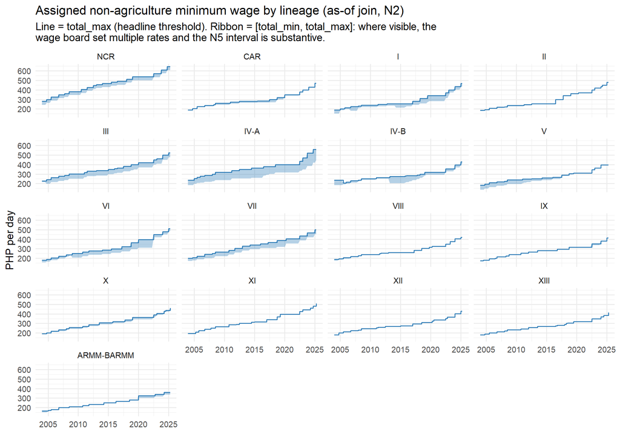

```r
# Quarterly grid of assigned rates for every lineage: the plotted steps must
# reproduce the wage-order table exactly (visual spot-check), and the shaded
# ribbon shows where total_min != total_max (the N5 interval is substantive).
qtr_grid <- expand_grid(region_wb = factor(REGION_ORDER, levels = REGION_ORDER),
                        year = 2004:2025, quarter = 1:4) %>%
  filter(!(year == 2025 & quarter > 2)) %>%
  mutate(ref_date = make_date(year, c(1, 4, 7, 10)[quarter], 1),
         mw_tot_max = assign_mw_lineage(ref_date, region_wb, "total_max"),
         mw_tot_min = assign_mw_lineage(ref_date, region_wb, "total_min"),
         mw_bas_max = assign_mw_lineage(ref_date, region_wb, "basic_max"),
         mw_bas_min = assign_mw_lineage(ref_date, region_wb, "basic_min"))

stopifnot("Every lineage-quarter must receive a MW" =
            !any(is.na(qtr_grid$mw_tot_max)))

ggplot(qtr_grid, aes(ref_date)) +
  geom_ribbon(aes(ymin = mw_tot_min, ymax = mw_tot_max),
              fill = "#2c7bb6", alpha = 0.35) +
  geom_step(aes(y = mw_tot_max), colour = "#2c7bb6", linewidth = 0.5) +
  facet_wrap(~region_wb, ncol = 4) +
  labs(title = "Assigned non-agriculture minimum wage by lineage (as-of join, N2)",
       subtitle = wrap_text("Line = total_max (headline threshold). Ribbon = [total_min, total_max]: where visible, the wage board set multiple rates and the N5 interval is substantive."),
       x = NULL, y = "PHP per day")
```

```r
qtr_grid %>%
  group_by(region_wb) %>%
  summarise(share_qtrs_multirate = mean(mw_tot_min < mw_tot_max),
            max_spread_php = max(mw_tot_max - mw_tot_min), .groups = "drop") %>%
  kt("Share of 2004-2025 quarters with total_min < total_max, and the widest peso spread, by lineage", digits = 2)
```

Share of 2004-2025 quarters with total_min < total_max, and the widest peso spread, by lineage

| region_wb | share_qtrs_multirate | max_spread_php |
| --- | --- | --- |
| NCR | 1.00 | 37 |
| CAR | 0.86 | 30 |
| I | 1.00 | 67 |
| II | 0.58 | 8 |
| III | 1.00 | 61 |
| IV-A | 1.00 | 140 |
| IV-B | 1.00 | 70 |
| V | 0.72 | 47 |
| VI | 0.99 | 85 |
| VII | 1.00 | 68 |
| VIII | 0.13 | 13 |
| IX | 0.08 | 28 |
| X | 1.00 | 27 |
| XI | 0.21 | 2 |
| XII | 0.00 | 0 |
| XIII | 0.01 | 10 |
| ARMM-BARMM | 0.30 | 25 |

**Reading.** Each panel is the statutory input to everything downstream: floors ratchet upward in nominal terms (wage orders never cut rates) at a roughly annual cadence, with visible freezes between orders. Where the ribbon is visible, the board set multiple non-agriculture rates and a single “the” minimum wage does not exist — 64% of all lineage-quarters are in that multi-rate state, which is why later compliance statistics are reported as intervals rather than points.

## 4.4 Regional CPI: parse, chain-continuity check, and deflators

The **primary** CPI source is `CPI_noNIR.xlsx` (pre-NIR configuration: Regions VI/VII *include* Negros, matching the lineage geography). The current-configuration workbook (`CPI.xlsx`, with NIR broken out and VI/VII recomputed) is loaded only for a configuration-difference table. Sheets are monthly, wide by `"YYYY Mon"` columns with `"YYYY Ave"` columns dropped; the three sheets needed for 1994–2025 appear pre-chained to 2018 = 100 by PSA — the continuity check below **verifies** this at each sheet junction instead of assuming it.

```r
# Region label -> lineage mapping for the CPI workbooks
cpi_region_map <- c(
  "National Capital Region (NCR)"            = "NCR",
  "Cordillera Administrative Region (CAR)"   = "CAR",
  "Region I (Ilocos Region)"                 = "I",
  "Region II (Cagayan Valley)"               = "II",
  "Region III (Central Luzon)"               = "III",
  "Region IV-A (CALABARZON)"                 = "IV-A",
  "MIMAROPA Region"                          = "IV-B",
  "Region V (Bicol Region)"                  = "V",
  "Region VI (Western Visayas)"              = "VI",
  "Region VII (Central Visayas)"             = "VII",
  "Region VIII (Eastern Visayas)"            = "VIII",
  "Region IX (Zamboanga Peninsula)"          = "IX",
  "Region X (Northern Mindanao)"             = "X",
  "Region XI (Davao Region)"                 = "XI",
  "Region XII (SOCCSKSARGEN)"                = "XII",
  "Region XIII (Caraga)"                     = "XIII",
  "Bangsamoro Autonomous Region in Muslim Mindanao (BARMM)" = "ARMM-BARMM"
)

# Parse one sheet: wide "YYYY Mon" columns -> long (region_wb, cpi_month, cpi)
parse_cpi_sheet <- function(path, sheet) {
  raw <- read_excel(path, sheet = sheet)
  names(raw)[1:2] <- c("geo", "commodity")
  raw %>%
    mutate(geo_clean = str_remove(str_trim(geo), "^\\.+")) %>%
    filter(str_starts(geo, "\\.\\.") & !str_starts(geo, "\\.\\.\\.\\."),
           geo_clean %in% names(cpi_region_map)) %>%
    mutate(region_wb = cpi_region_map[geo_clean]) %>%
    select(region_wb, matches("^\\d{4} ")) %>%
    # recent-month columns can arrive as character (blank / ".." cells);
    # coerce everything to character first, numeric after the pivot
    mutate(across(-region_wb, as.character)) %>%
    pivot_longer(-region_wb, names_to = "ym", values_to = "cpi") %>%
    filter(!str_ends(ym, "Ave")) %>%
    mutate(yr  = as.integer(str_sub(ym, 1, 4)),
           mon = match(str_sub(ym, 6), month.abb),
           cpi_month = make_date(yr, mon, 1),
           cpi = as.numeric(cpi)) %>%
    filter(!is.na(cpi)) %>%
    select(region_wb, cpi_month, cpi)
}

cpi_sheets <- c("1994-2006", "2006-2017", "2018-")
cpi_long <- map(cpi_sheets, ~ parse_cpi_sheet(params$cpi_path, .x)) %>%
  list_rbind() %>%
  distinct(region_wb, cpi_month, .keep_all = TRUE) %>%   # guard vs overlap
  mutate(region_wb = factor(region_wb, levels = REGION_ORDER)) %>%
  arrange(region_wb, cpi_month)

cat("CPI region-months parsed:", comma(nrow(cpi_long)),
    " | coverage:", format(min(cpi_long$cpi_month)), "to",
    format(max(cpi_long$cpi_month)), "\n")
```

```
## CPI region-months parsed: 6,392  | coverage: 1994-01-01 to 2025-04-01
```

```r
# National (PHILIPPINES) series, used only in the NCR reconciliation section
parse_cpi_national <- function(path, sheet) {
  raw <- read_excel(path, sheet = sheet)
  names(raw)[1:2] <- c("geo", "commodity")
  raw %>% filter(str_trim(geo) == "PHILIPPINES") %>%
    select(matches("^\\d{4} ")) %>%
    mutate(across(everything(), as.character)) %>%
    pivot_longer(everything(), names_to = "ym", values_to = "cpi") %>%
    filter(!str_ends(ym, "Ave")) %>%
    mutate(yr = as.integer(str_sub(ym, 1, 4)),
           mon = match(str_sub(ym, 6), month.abb),
           cpi_month = make_date(yr, mon, 1), cpi = as.numeric(cpi)) %>%
    filter(!is.na(cpi)) %>% select(cpi_month, cpi)
}
cpi_nat <- map(cpi_sheets, ~ parse_cpi_national(params$cpi_path, .x)) %>%
  list_rbind() %>% distinct(cpi_month, .keep_all = TRUE) %>% arrange(cpi_month)
```

### 4.4.1 Validation: chain continuity at sheet junctions

The workbooks are supplied as a single chained series (2018 = 100). If that is true, the implied month-on-month log change at each sheet junction (Dec 2005 → Jan 2006, Dec 2017 → Jan 2018) should look like ordinary monthly inflation. Junction changes above 5% in absolute value stop the document.

```r
junctions <- as.Date(c("2006-01-01", "2018-01-01"))

continuity <- cpi_long %>%
  group_by(region_wb) %>%
  arrange(cpi_month, .by_group = TRUE) %>%
  mutate(mom_log = log(cpi) - log(lag(cpi))) %>%
  ungroup() %>%
  filter(cpi_month %in% junctions) %>%
  select(region_wb, cpi_month, mom_log)

continuity %>%
  mutate(mom_pct = 100 * (exp(mom_log) - 1)) %>%
  select(-mom_log) %>%
  pivot_wider(names_from = cpi_month, values_from = mom_pct) %>%
  kt("Implied month-on-month inflation (%) across CPI sheet junctions -- values should look like ordinary monthly inflation", digits = 2)
```

Implied month-on-month inflation (%) across CPI sheet junctions – values should look like ordinary monthly inflation

| region_wb | 2006-01-01 | 2018-01-01 |
| --- | --- | --- |
| NCR | 0.93 | 0.21 |
| CAR | 0.92 | -0.09 |
| I | 0.41 | 1.90 |
| II | 0.41 | 0.41 |
| III | 1.23 | 0.57 |
| IV-A | 0.72 | 0.71 |
| IV-B | 0.51 | 0.92 |
| V | 1.23 | 2.32 |
| VI | 0.72 | 1.20 |
| VII | 0.72 | 1.50 |
| VIII | 0.51 | 0.39 |
| IX | 0.21 | 2.29 |
| X | 0.31 | 0.45 |
| XI | 1.55 | 0.99 |
| XII | 1.13 | 1.35 |
| XIII | 1.03 | 0.88 |
| ARMM-BARMM | 1.25 | 0.82 |

```r
stopifnot("CPI chain discontinuity > 5% at a sheet junction" =
            all(abs(continuity$mom_log) < 0.05, na.rm = TRUE))
```

### 4.4.2 Deflators (N3) and the configuration-difference table

```r
# (N3): defl_{r,m} = CPI_{r,m} / mean(CPI_{r, months of 2018});
#       real_x = x / defl. If the file is exactly 2018-based, the base
#       means printed below are ~100 and the rebasing is an identity.
cpi_base <- cpi_long %>%
  filter(year(cpi_month) == BASE_YEAR) %>%
  group_by(region_wb) %>%
  summarise(cpi_base_2018 = mean(cpi), .groups = "drop")

# Compact verification instead of a 17-row table: if the workbook is truly
# 2018-based, every regional 2018 mean is ~100.
cat(sprintf("Region 2018 mean CPI across lineages: min %.2f, max %.2f %s\n",
            min(cpi_base$cpi_base_2018), max(cpi_base$cpi_base_2018),
            if (all(abs(cpi_base$cpi_base_2018 - 100) < 2))
              "-- consistent with a 2018=100 base; rebasing is an identity."
            else
              "-- NOT all ~100; the explicit rebasing below is doing real work."))
```

```
## Region 2018 mean CPI across lineages: min 99.98, max 100.01 -- consistent with a 2018=100 base; rebasing is an identity.
```

```r
cpi_defl <- cpi_long %>%
  left_join(cpi_base, by = "region_wb") %>%
  mutate(defl = cpi / cpi_base_2018)

# Configuration difference: current PSA (NIR-configured) VI/VII vs the
# pre-NIR series used here, latest common month. Reference only.
cpi_nir_2018 <- parse_cpi_sheet(params$cpi_nir_path, "2018-") %>%
  filter(region_wb %in% c("VI", "VII"))
cfg_diff <- cpi_nir_2018 %>%
  rename(cpi_nir_cfg = cpi) %>%
  inner_join(cpi_long %>% rename(cpi_pre_nir = cpi),
             by = c("region_wb", "cpi_month")) %>%
  group_by(region_wb) %>% slice_max(cpi_month, n = 1) %>% ungroup() %>%
  mutate(pct_diff = 100 * (cpi_nir_cfg / cpi_pre_nir - 1))
kt(cfg_diff, "Regions VI/VII: current PSA (Negros-excluding) vs pre-NIR (Negros-including) CPI, latest common month. The pre-NIR series is the one used throughout, matching lineage geography.", digits = 2)
```

Regions VI/VII: current PSA (Negros-excluding) vs pre-NIR (Negros-including) CPI, latest common month. The pre-NIR series is the one used throughout, matching lineage geography.

| region_wb | cpi_month | cpi_nir_cfg | cpi_pre_nir | pct_diff |
| --- | --- | --- | --- | --- |
| VI | 2025-04-01 | 126.2 | 130.5 | -3.30 |
| VII | 2025-04-01 | 121.3 | 121.8 | -0.41 |

## 4.5 Poverty thresholds: vintages, conversion, and monthly projection

`PovertyThresholds.xlsx` carries **annual per-capita** thresholds by region for five methodology vintages at (mostly) triennial survey years. The rules implemented here, per the design discussion:

- **Series in force** (later vintage preferred at overlaps, but the pre-NIR-geography vintage retained through 2021 for consistency with the lineage boundaries): 2003 ← `2000-2006`; 2006, 2009, 2012 ← `2006-2015`; 2015, 2018, 2021 ← `2015-2021 (No NIR)`; 2023 ← `2018-2023 (With NIR)`.
- The 2023 (with-NIR) VI/VII values **exclude Negros** while our VI/VII lineages include it — a documented approximation for 2023+ (the NIR row is not separately usable at lineage level). Overlap ratios below show the size of every vintage/geography seam.
- **(N9)** conversion to a daily-wage equivalent, then **(N10)** CPI projection to monthly frequency, with linear interpolation as sensitivity.

```r
pt_raw <- read_excel(params$pt_path, sheet = "Thresholds")

pt_region_map <- c(
  "NCR" = "NCR", "CAR" = "CAR",
  "Region I - Ilocos" = "I", "Region II - Cagayan Valley" = "II",
  "Region III - Central Luzon" = "III",
  "Region IVA - CALABARZON" = "IV-A", "Region IVB - MIMAROPA" = "IV-B",
  "Region V - Bicol" = "V", "Region VI - Western Visayas" = "VI",
  "Region VII - Central Visayas" = "VII",
  "Region VIII - Eastern Visayas" = "VIII",
  "Region IX - Zamboanga Peninsula" = "IX",
  "Region X - Northern Mindanao" = "X",
  "Region XI - Davao" = "XI", "Region XII - SOCCSKSARGEN" = "XII",
  "Region XIII - Caraga" = "XIII",
  "ARMM" = "ARMM-BARMM", "BARMM" = "ARMM-BARMM"
)

pt_long <- pt_raw %>%
  pivot_longer(-c(Series, Region), names_to = "pt_year",
               values_to = "pt_percap_ann") %>%
  mutate(pt_year = as.integer(pt_year)) %>%
  filter(!is.na(pt_percap_ann), Region %in% names(pt_region_map)) %>%
  mutate(region_wb = factor(pt_region_map[Region], levels = REGION_ORDER))

# Series-in-force rule
series_in_force <- tribble(
  ~pt_year, ~Series,
  2003, "2000-2006",
  2006, "2006-2015", 2009, "2006-2015", 2012, "2006-2015",
  2015, "2015-2021 (No NIR)", 2018, "2015-2021 (No NIR)",
  2021, "2015-2021 (No NIR)",
  2023, "2018-2023 (With NIR)"
)

pt_inforce <- pt_long %>%
  inner_join(series_in_force, by = c("pt_year", "Series")) %>%
  select(region_wb, pt_year, pt_percap_ann) %>%
  arrange(region_wb, pt_year)

stopifnot("Every lineage must have every in-force threshold year" =
  nrow(pt_inforce) == length(REGION_ORDER) * nrow(series_in_force))
```

### 4.5.1 Validation: vintage overlap ratios

```r
# Where two vintages publish the same (region, year), their ratio measures
# the methodology / geography revision at that seam.
pt_overlap <- pt_long %>%
  group_by(region_wb, pt_year) %>%
  filter(n() > 1) %>%
  arrange(Series, .by_group = TRUE) %>%
  summarise(series_pair = paste(Series, collapse = "  vs  "),
            ratio_later_over_earlier = pt_percap_ann[n()] / pt_percap_ann[1],
            .groups = "drop")

pt_overlap %>%
  pivot_wider(names_from = pt_year, values_from = ratio_later_over_earlier,
              id_cols = region_wb) %>%
  kt("Vintage overlap ratios (later series / earlier series) at shared survey years. Values far from 1 mark methodology or geography revisions; the VI/VII 2018-2021 columns include the Negros-exclusion seam.", digits = 3)
```

Vintage overlap ratios (later series / earlier series) at shared survey years. Values far from 1 mark methodology or geography revisions; the VI/VII 2018-2021 columns include the Negros-exclusion seam.

| region_wb | 2000 | 2006 | 2015 | 2018 | 2021 |
| --- | --- | --- | --- | --- | --- |
| NCR | 0.888 | 0.763 | 1.007 | 1.000 | 1.000 |
| CAR | 0.842 | 0.839 | 1.056 | 1.000 | 1.000 |
| I | 0.860 | 0.884 | 1.111 | 1.000 | 1.000 |
| II | 0.901 | 1.011 | 1.035 | 1.000 | 1.000 |
| III | 0.940 | 0.834 | 0.986 | 1.000 | 1.000 |
| IV-A | NA | 0.746 | 1.159 | 1.000 | 1.000 |
| IV-B | NA | 0.854 | 1.007 | 1.000 | 1.000 |
| V | 0.887 | 0.882 | 1.048 | 1.000 | 1.000 |
| VI | 0.898 | 0.881 | 1.040 | 1.030 | 1.009 |
| VII | 0.873 | 1.043 | 1.033 | 1.009 | 1.039 |
| VIII | 0.884 | 0.896 | 1.051 | 1.000 | 1.000 |
| IX | NA | 0.964 | 1.078 | 1.000 | 1.000 |
| X | 0.864 | 0.910 | 1.030 | 1.000 | 1.000 |
| XI | NA | 0.896 | 1.017 | 1.000 | 1.000 |
| XII | NA | 0.936 | 1.015 | 1.000 | 1.000 |
| XIII | NA | 0.939 | 1.010 | 1.000 | 1.000 |
| ARMM-BARMM | 0.879 | 0.814 | 1.050 | 1.000 | 0.963 |

### 4.5.2 Conversion (N9) and monthly projection (N10)

```r
# (N9): PT_wage(r, y) = PT_percap_ann(r, y) * FAMILY_SIZE / (EARNERS * FACTOR_DAYS)
pt_wage_y <- pt_inforce %>%
  mutate(pt_wage_daily     = pt_percap_ann * FAMILY_SIZE / (EARNERS * FACTOR_DAYS),
         pt_wage_daily_365 = pt_percap_ann * FAMILY_SIZE / (EARNERS * FACTOR_DAYS_ALT))

# Annual-mean CPI per (lineage, year) -- the denominator of (N10)
cpi_ann <- cpi_defl %>%
  group_by(region_wb, yr = year(cpi_month)) %>%
  summarise(cpi_ann = mean(cpi), .groups = "drop")

# (N10): PT_wage(r, m) = PT_wage(r, y*) * CPI(r, m) / CPI_ann(r, y*),
#        y* = max{ threshold years <= year(m) }.
pt_monthly <- cpi_defl %>%
  select(region_wb, cpi_month, cpi) %>%
  mutate(yr = year(cpi_month)) %>%
  filter(yr >= 2004) %>%
  left_join(
    pt_wage_y %>% rename(pt_anchor_year = pt_year),
    by = "region_wb", relationship = "many-to-many"
  ) %>%
  filter(pt_anchor_year <= yr) %>%
  group_by(region_wb, cpi_month) %>%
  slice_max(pt_anchor_year, n = 1) %>%      # y* = latest anchor not after m
  ungroup() %>%
  left_join(cpi_ann, by = c("region_wb", "pt_anchor_year" = "yr")) %>%
  mutate(pt_wage_m     = pt_wage_daily     * cpi / cpi_ann,
         pt_wage_m_365 = pt_wage_daily_365 * cpi / cpi_ann) %>%
  select(region_wb, cpi_month, pt_anchor_year, pt_wage_m, pt_wage_m_365)

# Sensitivity: LINEAR interpolation in nominal levels between survey-year
# anchors placed at July 1 of each survey year; no extrapolation past the
# last anchor. approx(..., rule = 1) returns NA outside the anchor range.
pt_linear <- pt_wage_y %>%
  mutate(anchor_date = make_date(pt_year, 7, 1)) %>%
  group_by(region_wb) %>%
  reframe({
    grid <- seq(make_date(2004, 1, 1), make_date(2025, 6, 1), by = "month")
    tibble(cpi_month = grid,
           pt_wage_linear = approx(x = as.numeric(anchor_date),
                                   y = pt_wage_daily,
                                   xout = as.numeric(grid), rule = 1)$y)
  })

pt_monthly <- pt_monthly %>%
  left_join(pt_linear, by = c("region_wb", "cpi_month"))
```

### 4.5.3 The spatial price index $\theta_r$ (N13)

This is the **primary analytic use of the poverty thresholds in this document**: their 2018 cross-region ratios index price *levels* across regions (which the CPI cannot), so that a real ₱25 means the same purchasing power everywhere once combined with the CPI’s within-region time indexing. The wage-adequacy statistics later on are auxiliary.

```r
# (N13): theta_r = PT^pc_{r,2018} / PT^pc_{NCR,2018}  (No-NIR vintage).
# Family-size / earner / factor-day constants cancel in the ratio.
theta_tbl <- pt_inforce %>%
  filter(pt_year == 2018) %>%
  transmute(region_wb,
            theta = pt_percap_ann / pt_percap_ann[region_wb == SPATIAL_BASE])
stopifnot(nrow(theta_tbl) == length(REGION_ORDER),
          abs(theta_tbl$theta[theta_tbl$region_wb == SPATIAL_BASE] - 1) < 1e-12)

theta_tbl %>%
  mutate(band_width_local_php = AT_MW_BAND_PHP_REAL * theta) %>%
  kt(sprintf("Spatial price index theta (base: %s = 1) and the local real-2018-peso width of the 'P25' band in each region", SPATIAL_BASE), digits = 3)
```

Spatial price index theta (base: NCR = 1) and the local real-2018-peso width of the ‘P25’ band in each region

| region_wb | theta | band_width_local_php |
| --- | --- | --- |
| NCR | 1.000 | 25.000 |
| CAR | 0.868 | 21.709 |
| I | 0.943 | 23.582 |
| II | 0.875 | 21.876 |
| III | 0.940 | 23.494 |
| IV-A | 0.974 | 24.342 |
| IV-B | 0.813 | 20.322 |
| V | 0.853 | 21.321 |
| VI | 0.854 | 21.350 |
| VII | 0.898 | 22.440 |
| VIII | 0.871 | 21.779 |
| IX | 0.894 | 22.357 |
| X | 0.866 | 21.647 |
| XI | 0.905 | 22.621 |
| XII | 0.872 | 21.811 |
| XIII | 0.885 | 22.117 |
| ARMM-BARMM | 0.966 | 24.157 |

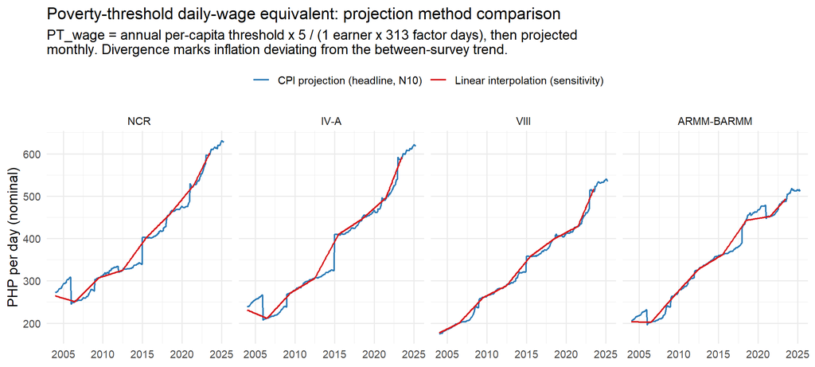

```r
# Overlay for four contrasting lineages: where CPI projection and linear
# interpolation diverge is exactly where inflation deviated from the
# between-survey trend (2018, 2022-23 spikes).
pt_monthly %>%
  filter(region_wb %in% c("NCR", "IV-A", "VIII", "ARMM-BARMM")) %>%
  pivot_longer(c(pt_wage_m, pt_wage_linear),
               names_to = "method", values_to = "pt") %>%
  mutate(method = recode(method,
                         pt_wage_m = "CPI projection (headline, N10)",
                         pt_wage_linear = "Linear interpolation (sensitivity)")) %>%
  ggplot(aes(cpi_month, pt, colour = method)) +
  geom_line(linewidth = 0.7, na.rm = TRUE) +
  facet_wrap(~region_wb, ncol = 4) +
  scale_colour_manual(values = c("#2c7bb6", "#d7191c")) +
  labs(title = "Poverty-threshold daily-wage equivalent: projection method comparison",
       subtitle = wrap_text(sprintf(
         "PT_wage = annual per-capita threshold x %d / (%d earner x %d factor days), then projected monthly. Divergence marks inflation deviating from the between-survey trend.",
         FAMILY_SIZE, EARNERS, FACTOR_DAYS)),
       x = NULL, y = "PHP per day (nominal)", colour = NULL) +
  theme(legend.position = "top")
```

## 4.6 Merge: LFS × wage orders × CPI × poverty thresholds

Merge keys are **(lineage, reference month)** throughout; the wage-order side enters through the as-of function (N2) evaluated at `ref_date`, the CPI and poverty sides join on the calendar month of `ref_date`.

```r
lfs <- lfs %>%
  mutate(
    mw_tot_max = assign_mw_lineage(ref_date, region_wb, "total_max"),
    mw_tot_min = assign_mw_lineage(ref_date, region_wb, "total_min"),
    mw_bas_max = assign_mw_lineage(ref_date, region_wb, "basic_max"),
    mw_bas_min = assign_mw_lineage(ref_date, region_wb, "basic_min")
  ) %>%
  left_join(cpi_defl %>% select(region_wb, cpi_month, defl),
            by = c("region_wb", "ref_date" = "cpi_month")) %>%
  left_join(pt_monthly %>% select(region_wb, cpi_month, pt_wage_m,
                                  pt_wage_m_365, pt_wage_linear),
            by = c("region_wb", "ref_date" = "cpi_month")) %>%
  left_join(theta_tbl, by = "region_wb")   # spatial index (N13)

merge_diag <- lfs %>%
  summarise(n = n(),
            pct_mw_na   = 100 * mean(is.na(mw_tot_max)),
            pct_defl_na = 100 * mean(is.na(defl)),
            pct_pt_na   = 100 * mean(is.na(pt_wage_m)),
            pct_theta_na = 100 * mean(is.na(theta)))
kt(merge_diag, "Merge diagnostics: share of LFS rows lacking an assigned MW / deflator / poverty wage (all should be 0)", digits = 3)
```

Merge diagnostics: share of LFS rows lacking an assigned MW / deflator / poverty wage (all should be 0)

| n | pct_mw_na | pct_defl_na | pct_pt_na | pct_theta_na |
| --- | --- | --- | --- | --- |
| 18817578 | 0 | 0 | 0 | 0 |

```r
stopifnot(merge_diag$pct_mw_na == 0, merge_diag$pct_defl_na == 0)
```

# 5 Sample Construction: the A / B / C Cascade

Three nested samples, per the agreed convention. **Only Sample C** feeds the Kaitz, compliance-partition, bunching, and wage-bin sections; Samples A and B appear in the descriptive trends and the reconciliation.

- **Sample A (naive):** employed, positive reported daily basic pay, age 15–64 — *every* pay report regardless of class or industry.
- **Sample B (wage workers):** A ∩ `class_label` ∈ {Private Establishment, Government/GOCC, Private Household} — the NCR-PoC-comparable universe.
- **Sample C (covered sector):** B ∩ `class_label` = Private Establishment ∩ non-agriculture (`ind_section ≠ "A"`, non-missing) — the universe the non-agriculture wage orders actually govern (less the establishment-size and apprentice exemptions the LFS cannot observe; see the Limitations register).

```r
base <- lfs %>%
  mutate(pay_ok = !is.na(basic_pay_php) & basic_pay_php > 0,
         age_ok = age_years >= 15 & age_years <= 64,
         w_ok   = !is.na(weight) & weight > 0)

sample_A <- base %>% filter(employed == 1, pay_ok, age_ok, w_ok)
sample_B <- sample_A %>% filter(class_label %in% WAGE_CLASS_LABELS)
sample_C <- sample_B %>% filter(class_label == COVERED_CLASS,
                                !is.na(ind_section), ind_section != "A")

waterfall <- tribble(
  ~step, ~restriction, ~n_unwt, ~pop_wt,
  "0", "All LFS person-quarters (mapped to a lineage)",
       nrow(base), sum(base$weight, na.rm = TRUE),
  "A", "Employed, positive daily basic pay, age 15-64, valid weight",
       nrow(sample_A), sum(sample_A$weight),
  "B", "A and wage-worker class (Priv. Est. / Gov't / Priv. HH)",
       nrow(sample_B), sum(sample_B$weight),
  "C", "B and Private Establishment only, non-agriculture",
       nrow(sample_C), sum(sample_C$weight)
) %>%
  mutate(pct_of_A_unwt = 100 * n_unwt / n_unwt[step == "A"],
         pop_wt_m = pop_wt / 1e6)

waterfall %>% select(-pop_wt) %>%
  kt("Sample-construction waterfall (pooled 2004-2025). pop_wt_m = weighted person-quarters, millions.",
     digits = c(NA, NA, 0, 1, 1), format.args = list(big.mark = ","))
```

Sample-construction waterfall (pooled 2004-2025). pop_wt_m = weighted person-quarters, millions.

| step | restriction | n_unwt | pct_of_A_unwt | pop_wt_m |
| --- | --- | --- | --- | --- |
| 0 | All LFS person-quarters (mapped to a lineage) | 18,817,578 | 535.2 | 8,574.1 |
| A | Employed, positive daily basic pay, age 15-64, valid weight | 3,516,250 | 100.0 | 1,690.1 |
| B | A and wage-worker class (Priv. Est. / Gov’t / Priv. HH) | 3,499,107 | 99.5 | 1,681.6 |
| C | B and Private Establishment only, non-agriculture | 2,170,041 | 61.7 | 1,094.9 |

```r
# Where does the agriculture exclusion bite? Weighted share of Sample-B
# Private Establishment workers in ind_section "A", by lineage.
agri_exit <- sample_B %>%
  filter(class_label == COVERED_CLASS) %>%
  group_by(region_wb) %>%
  summarise(pct_agri_wt = 100 * wshare(!is.na(ind_section) & ind_section == "A", weight),
            pct_ind_na  = 100 * wshare(is.na(ind_section), weight),
            .groups = "drop")
kt(agri_exit, "Weighted share of private-establishment wage workers excluded at the B->C step: agriculture workers (no matching rate in the panel) and missing-industry rows, by lineage", digits = 1)
```

Weighted share of private-establishment wage workers excluded at the B->C step: agriculture workers (no matching rate in the panel) and missing-industry rows, by lineage

| region_wb | pct_agri_wt | pct_ind_na |
| --- | --- | --- |
| NCR | 0.3 | 0 |
| CAR | 19.8 | 0 |
| I | 20.8 | 0 |
| II | 45.5 | 0 |
| III | 11.5 | 0 |
| IV-A | 5.3 | 0 |
| IV-B | 30.1 | 0 |
| V | 23.3 | 0 |
| VI | 30.6 | 0 |
| VII | 9.0 | 0 |
| VIII | 30.2 | 0 |
| IX | 23.9 | 0 |
| X | 31.0 | 0 |
| XI | 30.1 | 0 |
| XII | 36.2 | 0 |
| XIII | 24.3 | 0 |
| ARMM-BARMM | 27.5 | 0 |

```r
# Low-N flags at the analysis resolution (lineage x quarter, Sample C).
cell_n <- sample_C %>% count(region_wb, ref_date, name = "n_C")
low_cells <- cell_n %>% filter(n_C < MIN_CELL_N)
cat("Sample-C lineage-quarters below the low-N flag (", MIN_CELL_N, "obs ):",
    nrow(low_cells), "of", nrow(cell_n), "\n")
```

```
## Sample-C lineage-quarters below the low-N flag ( 30 obs ): 0 of 1461
```

```r
if (nrow(low_cells) > 0) {
  low_cells %>% count(region_wb, name = "n_flagged_quarters") %>%
    kt("Low-N lineage-quarter counts by lineage (estimates in these cells are noisy; they remain in charts but are not separately suppressed)")
}
```

### 5.0.1 Payment-basis check

```r
# payment_label records PERIODICITY (Monthly / Per Day / ...); basic_pay_php
# is already the daily equivalent regardless (confirmed convention). In-kind
# pay is a peso-valued estimate rather than a cash wage; its share is
# reported here and it is retained in the sample (PoC convention).
sample_C %>%
  count(payment_label, wt = weight, name = "pop_wt") %>%
  mutate(pct_wt = 100 * pop_wt / sum(pop_wt)) %>%
  arrange(desc(pct_wt)) %>%
  kt("payment_label (periodicity of pay) among Sample C, weighted shares", digits = 1)
```

payment_label (periodicity of pay) among Sample C, weighted shares

| payment_label | pop_wt | pct_wt |
| --- | --- | --- |
| Per Day | 565070828.5 | 51.6 |
| Monthly | 471354948.4 | 43.0 |
| Per Piece (Pakkyaw) | 24063287.6 | 2.2 |
| Pakyaw (Task Basis) | 14251969.3 | 1.3 |
| Other Wages/Salaries | 10933029.9 | 1.0 |
| Per Hour | 8311297.0 | 0.8 |
| In Kind Only | 960942.0 | 0.1 |
| Commission | 3168.2 | 0.0 |

# 6 The Master Quarterly Panel

All bindingness statistics are computed **once**, here, into a single lineage × quarter panel (`bind_qtr`) plus its person-level-pooled national counterpart (`bind_nat`, per N11). Every downstream bindingness chart reads from these two tables, so a formula is implemented in exactly one place.

```r
# Per (lineage, quarter) on Sample C -- formulas N1, N4, N5, N6:
#   percentiles: Q(p) via weighted_quantile (N1)
#   kaitz_med   = mw_tot_max / Q(0.50)                     (N4)
#   kaitz_mean  = mw_tot_max / weighted mean               (N4)
#   F_at_below  = Fhat(mw_tot_max)          [w <= MW, weak] (N4)
#   B_max/B_min = Pr[w < mw_tot_max] / Pr[w < mw_tot_min]  (N5, strict)
#   partition   = below (w < .95 MW) / at (|w/MW-1|<=.05) / above (N6)
#   at_real25s  = |real w - real MW| <= 25 * theta_r        (N6 sensitivity,
#                 spatially indexed per N13; identical to the PoC in NCR)
#   B_bas_max   = Pr[w < mw_bas_max]  (basic-rate sensitivity, Robustness section)
#   below_pt    = Pr[w < PT_wage_m]                         (N9/N10)
bind_qtr <- sample_C %>%
  mutate(real_pay = basic_pay_php / defl,
         real_mw  = mw_tot_max   / defl) %>%
  group_by(region_wb, year, quarter, ref_date,
           mw_tot_max, mw_tot_min, mw_bas_max, pt_wage_m, theta) %>%
  summarise(
    n      = n(),
    pop_wt = sum(weight),
    p05 = weighted_quantile(basic_pay_php, weight, 0.05),
    p10 = weighted_quantile(basic_pay_php, weight, 0.10),
    p25 = weighted_quantile(basic_pay_php, weight, 0.25),
    p50 = weighted_quantile(basic_pay_php, weight, 0.50),
    p75 = weighted_quantile(basic_pay_php, weight, 0.75),
    p90 = weighted_quantile(basic_pay_php, weight, 0.90),
    mean_pay      = wmean(basic_pay_php, weight),
    p50_real      = weighted_quantile(real_pay, weight, 0.50),
    mean_pay_real = wmean(real_pay, weight),
    F_at_below    = wshare(basic_pay_php <= mw_tot_max, weight),
    B_max         = wshare(basic_pay_php <  mw_tot_max, weight),
    B_min         = wshare(basic_pay_php <  mw_tot_min, weight),
    B_bas_max     = wshare(basic_pay_php <  mw_bas_max, weight),
    part_below    = wshare(basic_pay_php / mw_tot_max - 1 < -AT_MW_BAND_PCT, weight),
    part_at       = wshare(abs(basic_pay_php / mw_tot_max - 1) <= AT_MW_BAND_PCT, weight),
    part_above    = wshare(basic_pay_php / mw_tot_max - 1 >  AT_MW_BAND_PCT, weight),
    at_real25s    = wshare(abs(real_pay - real_mw) <= AT_MW_BAND_PHP_REAL * theta,
                           weight),
    below_pt      = wshare(basic_pay_php < pt_wage_m, weight),
    .groups = "drop"
  ) %>%
  mutate(kaitz_med    = mw_tot_max / p50,
         kaitz_mean   = mw_tot_max / mean_pay,
         kaitz_med_min = mw_tot_min / p50,
         low_n        = n < MIN_CELL_N)

# Real MW and real poverty wage at the cell level: divide by the same
# regional deflator (N3) used for wages.
bind_qtr <- bind_qtr %>%
  left_join(cpi_defl %>% select(region_wb, cpi_month, defl),
            by = c("region_wb", "ref_date" = "cpi_month")) %>%
  mutate(mw_real = mw_tot_max / defl,
         pt_real = pt_wage_m / defl)

# Partition must sum to 1 exactly (each obs in exactly one N6 class)
stopifnot(max(abs(bind_qtr$part_below + bind_qtr$part_at +
                  bind_qtr$part_above - 1), na.rm = TRUE) < 1e-9)

# National pooled panel (N11): person-level against own regional floor
bind_nat <- sample_C %>%
  mutate(real_pay = basic_pay_php / defl,
         real_mw  = mw_tot_max / defl) %>%
  group_by(year, quarter, ref_date) %>%
  summarise(
    n = n(), pop_wt = sum(weight),
    p10 = weighted_quantile(basic_pay_php, weight, 0.10),
    p50 = weighted_quantile(basic_pay_php, weight, 0.50),
    p90 = weighted_quantile(basic_pay_php, weight, 0.90),
    p50_real   = weighted_quantile(real_pay, weight, 0.50),
    mean_real  = wmean(real_pay, weight),
    F_at_below = wshare(basic_pay_php <= mw_tot_max, weight),
    B_max      = wshare(basic_pay_php <  mw_tot_max, weight),
    B_min      = wshare(basic_pay_php <  mw_tot_min, weight),
    B_bas_max  = wshare(basic_pay_php <  mw_bas_max, weight),
    part_below = wshare(basic_pay_php / mw_tot_max - 1 < -AT_MW_BAND_PCT, weight),
    part_at    = wshare(abs(basic_pay_php / mw_tot_max - 1) <= AT_MW_BAND_PCT, weight),
    part_above = wshare(basic_pay_php / mw_tot_max - 1 >  AT_MW_BAND_PCT, weight),
    at_real25s = wshare(abs(real_pay - real_mw) <= AT_MW_BAND_PHP_REAL * theta,
                        weight),
    below_pt   = wshare(basic_pay_php < pt_wage_m, weight),
    .groups = "drop"
  )

# National Kaitz (N11): covered-employment-weighted mean of regional Kaitz,
# with the cross-region min-max range.
kaitz_nat <- bind_qtr %>%
  group_by(year, quarter, ref_date) %>%
  summarise(kaitz_nat  = sum(pop_wt * kaitz_med) / sum(pop_wt),
            kaitz_min  = min(kaitz_med),
            kaitz_max  = max(kaitz_med), .groups = "drop")
```

# 7 Wage Levels: Mean and Median Trends

**Formula note.** Real series deflate by the *regional* CPI (N3); the national real median is the pooled weighted median of regionally-deflated wages — i.e., each peso is converted to 2018 purchasing power *in its own region* before pooling.

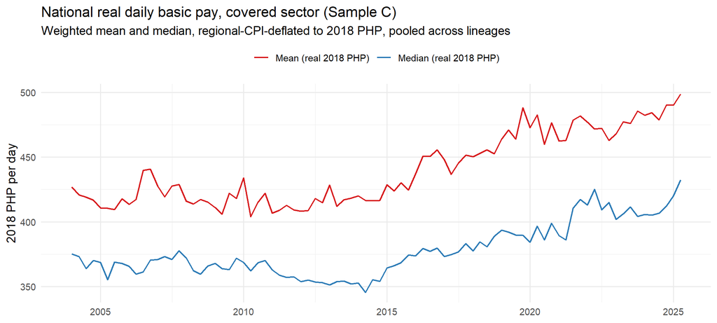

```r
bind_nat %>%
  select(ref_date, `Median (real 2018 PHP)` = p50_real,
         `Mean (real 2018 PHP)` = mean_real) %>%
  pivot_longer(-ref_date) %>%
  ggplot(aes(ref_date, value, colour = name)) +
  geom_line(linewidth = 0.7) +
  scale_colour_manual(values = c("#d7191c", "#2c7bb6")) +
  labs(title = "National real daily basic pay, covered sector (Sample C)",
       subtitle = "Weighted mean and median, regional-CPI-deflated to 2018 PHP, pooled across lineages",
       x = NULL, y = "2018 PHP per day", colour = NULL) +
  theme(legend.position = "top")
```

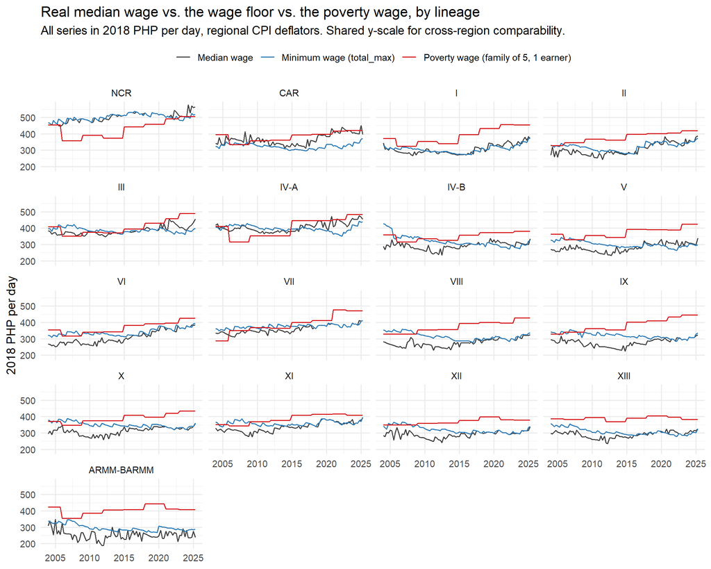

```r
bind_qtr %>%
  select(region_wb, ref_date, p50_real, mw_real, pt_real) %>%
  pivot_longer(-c(region_wb, ref_date)) %>%
  mutate(name = recode(name,
                       p50_real = "Median wage",
                       mw_real  = "Minimum wage (total_max)",
                       pt_real  = "Poverty wage (family of 5, 1 earner)")) %>%
  ggplot(aes(ref_date, value, colour = name)) +
  geom_line(linewidth = 0.5, na.rm = TRUE) +
  facet_wrap(~region_wb, ncol = 4) +
  scale_colour_manual(values = c("Median wage" = "grey25",
                                 "Minimum wage (total_max)" = "#2c7bb6",
                                 "Poverty wage (family of 5, 1 earner)" = "#d7191c")) +
  labs(title = "Real median wage vs. the wage floor vs. the poverty wage, by lineage",
       subtitle = "All series in 2018 PHP per day, regional CPI deflators. Shared y-scale for cross-region comparability.",
       x = NULL, y = "2018 PHP per day", colour = NULL) +
  theme(legend.position = "top")
```

**Reading.** The striking structural fact is how close the blue floor line runs to the grey median in most lineages — in 10 of 17 lineages the latest-quarter real floor sits at or above the covered-sector real median. The red poverty-wage line adds the adequacy anchor: where blue runs below red, even full compliance at the floor would not support the reference family. Co-movement of the three lines is expected by construction (all deflated by the same regional CPI) and is not evidence of causation in any direction.

# 8 Bindingness: The Kaitz Index

**Formulas (N4, N11).** $K^{med}_{r,t} = MW^{tot,max}_{r,t} / Q_{r,t}(0.5)$; the dashed companion uses $MW^{tot,min}$, so the vertical gap between the two lines is the pure multi-rate-interval effect on measured bindingness.

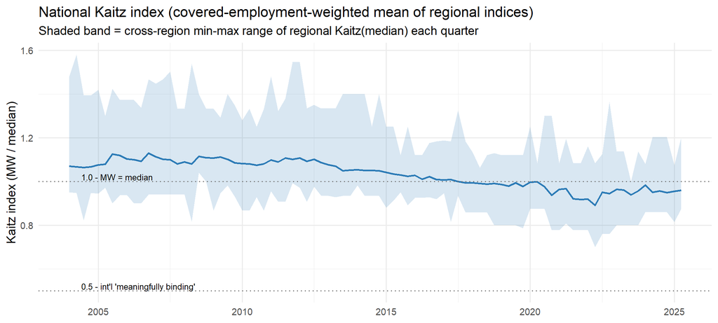

```r
ggplot(kaitz_nat, aes(ref_date)) +
  geom_ribbon(aes(ymin = kaitz_min, ymax = kaitz_max),
              fill = "#2c7bb6", alpha = 0.18) +
  geom_line(aes(y = kaitz_nat), colour = "#2c7bb6", linewidth = 0.9) +
  geom_hline(yintercept = c(0.5, 1.0), linetype = "dotted", colour = "grey45") +
  annotate("text", x = as.Date("2004-06-01"), y = 1.02,
           label = "1.0 - MW = median", hjust = 0, size = 3) +
  annotate("text", x = as.Date("2004-06-01"), y = 0.52,
           label = "0.5 - int'l 'meaningfully binding'", hjust = 0, size = 3) +
  labs(title = "National Kaitz index (covered-employment-weighted mean of regional indices)",
       subtitle = "Shaded band = cross-region min-max range of regional Kaitz(median) each quarter",
       x = NULL, y = "Kaitz index (MW / median)")
```

**Reading.** The latest national Kaitz index is 0.96, with regional indices spanning 0.88–1.20 in that quarter. Values in this neighbourhood are extraordinary by international standards — rich-country minimum wages typically sit near 0.5 of the median — and mean the Philippine floor is set at the *centre* of the covered wage distribution, not its tail. A high Kaitz signals where the floor is aimed; it does not by itself say whether the floor is complied with or what it does to employment.

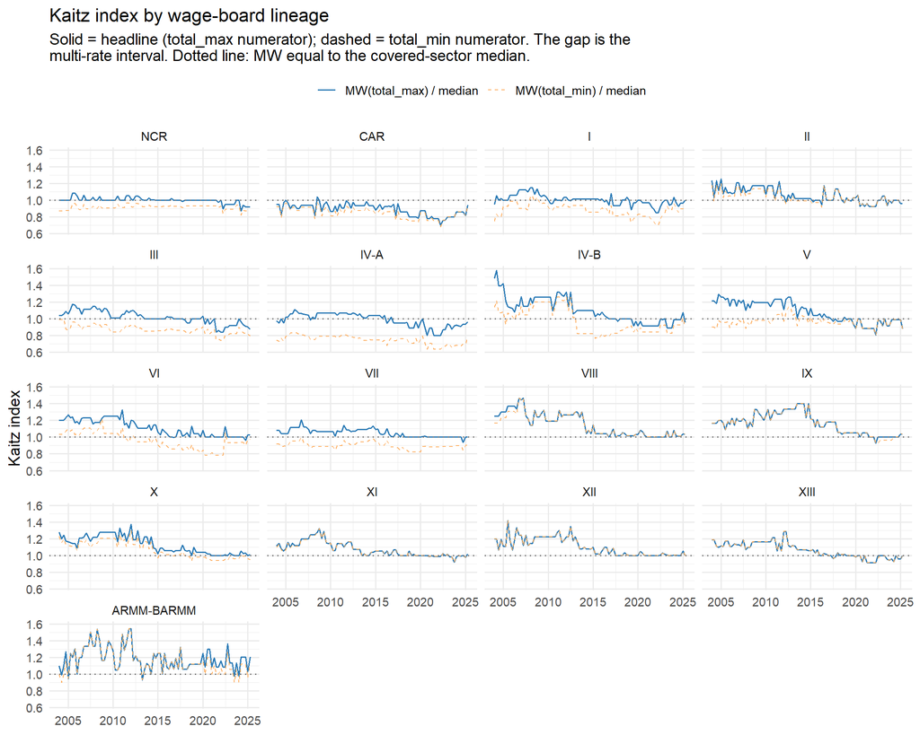

```r
bind_qtr %>%
  ggplot(aes(ref_date)) +
  geom_line(aes(y = kaitz_med, colour = "MW(total_max) / median"), linewidth = 0.5) +
  geom_line(aes(y = kaitz_med_min, colour = "MW(total_min) / median"),
            linewidth = 0.4, linetype = "dashed") +
  geom_hline(yintercept = 1, linetype = "dotted", colour = "grey45") +
  facet_wrap(~region_wb, ncol = 4) +
  scale_colour_manual(values = c("MW(total_max) / median" = "#2c7bb6",
                                 "MW(total_min) / median" = "#fdae61")) +
  labs(title = "Kaitz index by wage-board lineage",
       subtitle = wrap_text("Solid = headline (total_max numerator); dashed = total_min numerator. The gap is the multi-rate interval. Dotted line: MW equal to the covered-sector median."),
       x = NULL, y = "Kaitz index", colour = NULL) +
  theme(legend.position = "top")
```

**Reading.** Bindingness is high everywhere but not uniform: the spread between lineages, and within each panel the gap between the solid (total_max) and dashed (total_min) lines, shows how much of measured bindingness depends on which statutory rate is used as the ruler. Panels where the two lines separate widely are exactly the multi-rate boards flagged in the wage-order section; treat any single-line Kaitz quote for those regions with suspicion.

```r
bind_qtr %>%
  filter(quarter == 2, year %in% c(2004, 2009, 2014, 2019, 2024)) %>%
  select(region_wb, year, kaitz_med) %>%
  pivot_wider(names_from = year, values_from = kaitz_med) %>%
  kt("Kaitz(median) at Q2 of selected years, by lineage (Sample C)", digits = 2)
```

Kaitz(median) at Q2 of selected years, by lineage (Sample C)

| region_wb | 2004 | 2009 | 2014 | 2019 | 2024 |
| --- | --- | --- | --- | --- | --- |
| NCR | 1.00 | 1.00 | 1.00 | 1.00 | 0.87 |
| CAR | 0.95 | 0.95 | 0.93 | 0.80 | 0.86 |
| I | 1.06 | 1.04 | 1.01 | 0.89 | 0.97 |
| II | 1.03 | 1.18 | 1.02 | 1.00 | 1.00 |
| III | 1.04 | 1.12 | 1.00 | 1.00 | 0.96 |
| IV-A | 0.95 | 1.07 | 1.04 | 0.89 | 0.91 |
| IV-B | 1.58 | 1.26 | 1.10 | 1.00 | 0.99 |
| V | 1.21 | 1.20 | 1.13 | 1.00 | 0.99 |
| VI | 1.20 | 1.25 | 1.08 | 1.04 | 1.00 |
| VII | 1.08 | 1.07 | 1.11 | 1.00 | 1.00 |
| VIII | 1.25 | 1.28 | 1.04 | 1.02 | 1.01 |
| IX | 1.17 | 1.28 | 1.40 | 1.05 | 1.00 |
| X | 1.20 | 1.28 | 1.22 | 1.04 | 1.06 |
| XI | 1.15 | 1.29 | 1.00 | 1.02 | 1.00 |
| XII | 1.20 | 1.23 | 1.08 | 1.00 | 1.01 |
| XIII | 1.19 | 1.17 | 1.07 | 1.00 | 0.92 |
| ARMM-BARMM | 0.99 | 1.27 | 1.00 | 1.12 | 1.20 |

# 9 The Compliance Partition and the Noncompliance Interval

**Formulas.** The stacked partition is (N6): below ($w < 0.95\,MW$), at ($|w/MW - 1| \le 0.05$), above ($w > 1.05\,MW$), with $MW = MW^{tot,max}$. The interval chart is (N5): strict shares $B^{max} = \Pr[w < MW^{tot,max}]$ and $B^{min} = \Pr[w < MW^{tot,min}]$; true noncompliance lies inside the ribbon (up to the coverage caveats in the Limitations register).

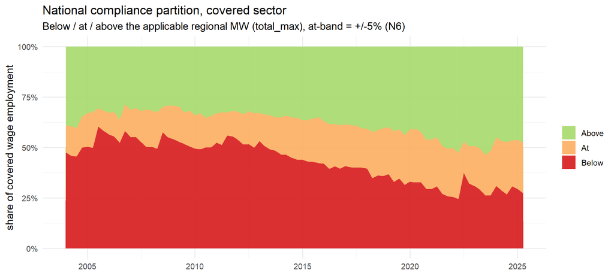

```r
bind_nat %>%
  select(ref_date, Below = part_below, At = part_at, Above = part_above) %>%
  pivot_longer(-ref_date, names_to = "band", values_to = "share") %>%
  mutate(band = factor(band, levels = c("Above", "At", "Below"))) %>%
  ggplot(aes(ref_date, share, fill = band)) +
  geom_area(alpha = 0.9) +
  scale_fill_manual(values = c(Above = "#a6d96a", At = "#fdae61", Below = "#d7191c")) +
  scale_y_continuous(labels = percent_format()) +
  labs(title = "National compliance partition, covered sector",
       subtitle = sprintf("Below / at / above the applicable regional MW (total_max), at-band = +/-%d%% (N6)", 100 * AT_MW_BAND_PCT),
       x = NULL, y = "share of covered wage employment", fill = NULL)
```

**Reading.** In the latest quarter, 27% of covered wage employment is paid more than 5% below the applicable floor, 25% within ±5% of it, and 48% above. The sawtooth texture is mechanical: each wage order instantly reclassifies workers relative to a higher ruler, after which nominal wage growth walks them back up. The below-band share bundles genuine noncompliance with lawful exemptions and rate-interval ambiguity — it is an upper-bound-flavoured measure, not a violation rate.

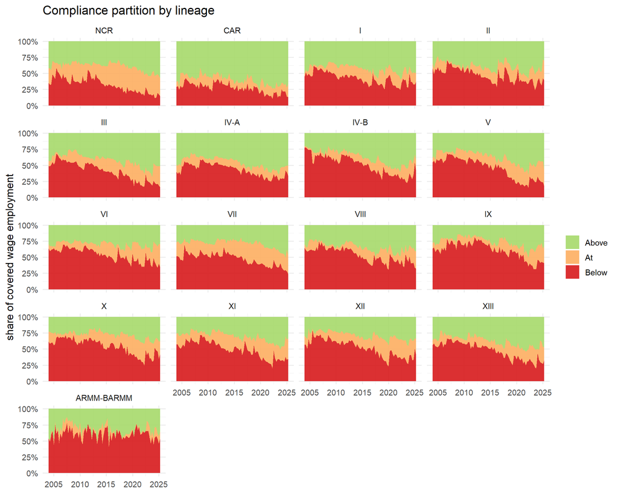

```r
bind_qtr %>%
  select(region_wb, ref_date, Below = part_below, At = part_at, Above = part_above) %>%
  pivot_longer(-c(region_wb, ref_date), names_to = "band", values_to = "share") %>%
  mutate(band = factor(band, levels = c("Above", "At", "Below"))) %>%
  ggplot(aes(ref_date, share, fill = band)) +
  geom_area(alpha = 0.9) +
  facet_wrap(~region_wb, ncol = 4) +
  scale_fill_manual(values = c(Above = "#a6d96a", At = "#fdae61", Below = "#d7191c")) +
  scale_y_continuous(labels = percent_format()) +
  labs(title = "Compliance partition by lineage", x = NULL,
       y = "share of covered wage employment", fill = NULL)
```

**Reading.** The same partition by lineage shows the compliance landscape is regional: some panels are dominated by the green above-band, others carry persistently large red below-band shares. Because the ±5% band is scale-invariant, these differences are not artifacts of wage levels — they reflect real differences in the floor’s position in each region’s distribution and in adherence to it. Cross-panel level differences are the motivation for reporting every national statistic alongside its facets.

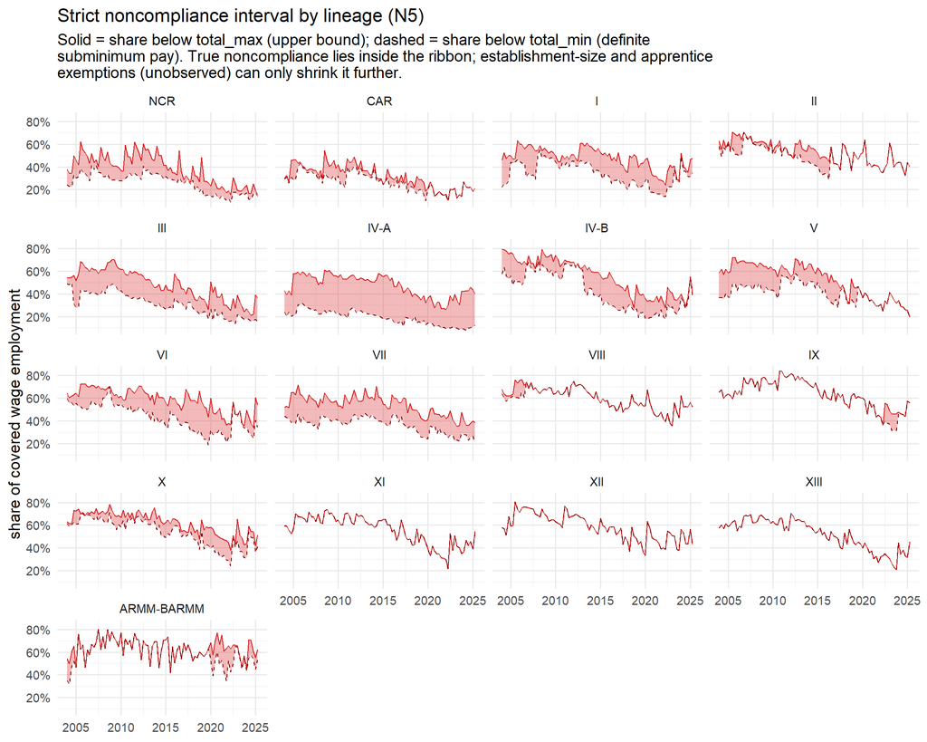

```r
bind_qtr %>%
  ggplot(aes(ref_date)) +
  geom_ribbon(aes(ymin = B_min, ymax = B_max), fill = "#d7191c", alpha = 0.3) +
  geom_line(aes(y = B_max), colour = "#d7191c", linewidth = 0.45) +
  geom_line(aes(y = B_min), colour = "#7f0000", linewidth = 0.45, linetype = "dashed") +
  facet_wrap(~region_wb, ncol = 4) +
  scale_y_continuous(labels = percent_format()) +
  labs(title = "Strict noncompliance interval by lineage (N5)",
       subtitle = wrap_text("Solid = share below total_max (upper bound); dashed = share below total_min (definite subminimum pay). True noncompliance lies inside the ribbon; establishment-size and apprentice exemptions (unobserved) can only shrink it further."),
       x = NULL, y = "share of covered wage employment")
```

**Reading.** The ribbon is the honest answer to “what share of workers is paid below the minimum wage?” — it depends on which minimum. The lower dashed line (below every applicable rate) is definite sub-minimum pay; the ribbon width is classification ambiguity from multi-rate boards, reaching 38 percentage points at its widest lineage-quarter. Unobserved exemptions (small retail, apprentices, BMBEs) can only shrink true noncompliance further below the upper line.

## 9.1 Reference modules: Government and Private Household (kasambahay)

These two classes are **outside** the covered sector: government pay is set by the Salary Standardization Law, and domestic workers fall under the Kasambahay Law’s separate (much lower) floor. Their strict share below the regional non-agriculture `total_max` is shown as *context*, not as a noncompliance estimate.

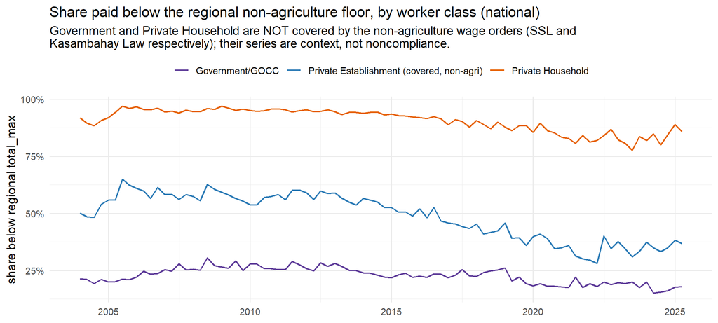

```r
ref_mod <- sample_B %>%
  filter(class_label != COVERED_CLASS) %>%
  group_by(class_label, ref_date) %>%
  summarise(B_max = wshare(basic_pay_php < mw_tot_max, weight),
            .groups = "drop")

bind_nat %>% transmute(class_label = "Private Establishment (covered, non-agri)",
                       ref_date, B_max) %>%
  bind_rows(ref_mod) %>%
  ggplot(aes(ref_date, B_max, colour = class_label)) +
  geom_line(linewidth = 0.7) +
  scale_y_continuous(labels = percent_format()) +
  scale_colour_manual(values = c("Private Establishment (covered, non-agri)" = "#2c7bb6",
                                 "Government/GOCC" = "#5e3c99",
                                 "Private Household" = "#e66101")) +
  labs(title = "Share paid below the regional non-agriculture floor, by worker class (national)",
       subtitle = wrap_text("Government and Private Household are NOT covered by the non-agriculture wage orders (SSL and Kasambahay Law respectively); their series are context, not noncompliance."),
       x = NULL, y = "share below regional total_max", colour = NULL) +
  theme(legend.position = "top")
```

**Reading.** The two reference series confirm the sample design rather than measure violations: Private Household workers sit overwhelmingly below the non-agriculture floor because the Kasambahay Law sets them a separate, much lower one, and Government pay follows the SSL. Their divergence from the covered-sector line is a coverage boundary, and it is why both classes are excluded from every compliance statistic in this document.

# 10 Auxiliary: The Poverty-Wage Adequacy Benchmark

**Role in this document.** The poverty thresholds’ *primary* job here is the N13 spatial index — making real-peso bands comparable across regions. This section is the *auxiliary* use: the thresholds as a wage-adequacy benchmark in their own right. It is retained because it is cheap and policy-legible, but nothing downstream depends on it.

**Disclaimer (stated once, meant everywhere):** a wage below $PT^{wage}_{r,m}$ is a **wage-adequacy** statistic — the daily basic pay is insufficient for a *hypothetical* single-earner family of five at the poverty line. It is **not** a poverty rate: actual household poverty depends on household size, number of earners, and non-wage income, none of which this statistic conditions on.

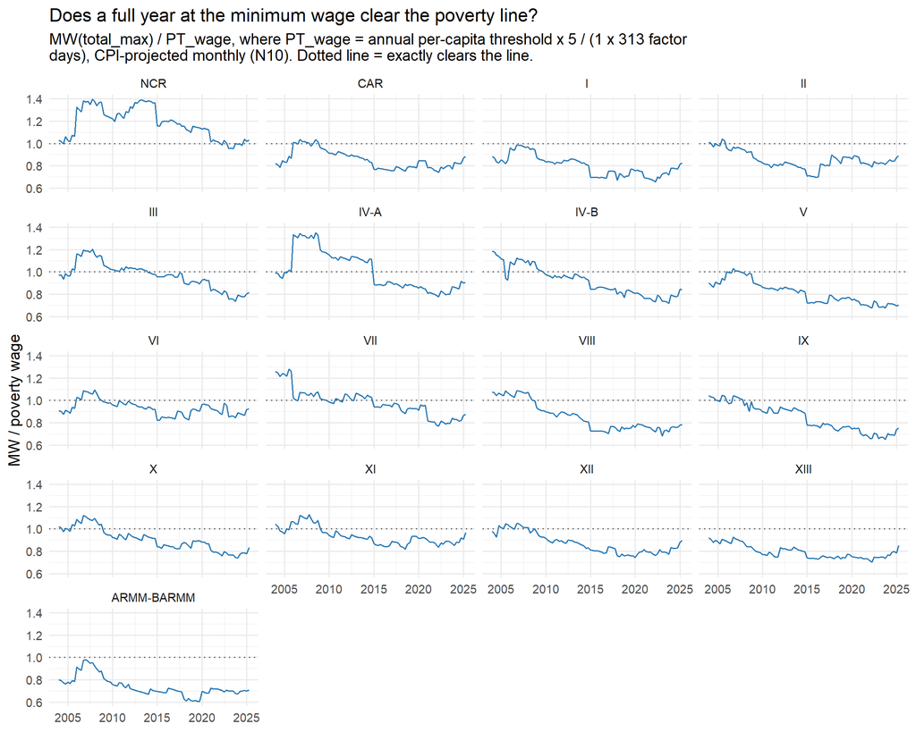

```r
# Ratio (N2, N9, N10): MW^{tot,max}_{r,m} / PT_wage_{r,m}. Values >= 1 mean
# a full factor-day year at the floor clears the poverty line for a
# family of five on one earner.
bind_qtr %>%
  mutate(mw_over_pt = mw_tot_max / pt_wage_m) %>%
  ggplot(aes(ref_date, mw_over_pt)) +
  geom_hline(yintercept = 1, linetype = "dotted", colour = "grey40") +
  geom_line(colour = "#2c7bb6", linewidth = 0.55) +
  facet_wrap(~region_wb, ncol = 4) +
  labs(title = "Does a full year at the minimum wage clear the poverty line?",
       subtitle = wrap_text(sprintf(
         "MW(total_max) / PT_wage, where PT_wage = annual per-capita threshold x %d / (%d x %d factor days), CPI-projected monthly (N10). Dotted line = exactly clears the line.",
         FAMILY_SIZE, EARNERS, FACTOR_DAYS)),
       x = NULL, y = "MW / poverty wage")
```

**Reading.** In the latest quarter the floor clears the family-of-five poverty wage in 1 of 17 lineages. The within-panel sawtooth repeats the erosion cycle: each order lifts the ratio, inflation grinds it back down. Remember the maintained assumptions — one earner, family of five, 313 paid days — before quoting any single ratio; the level shifts proportionally under other conventions, though the time pattern does not.

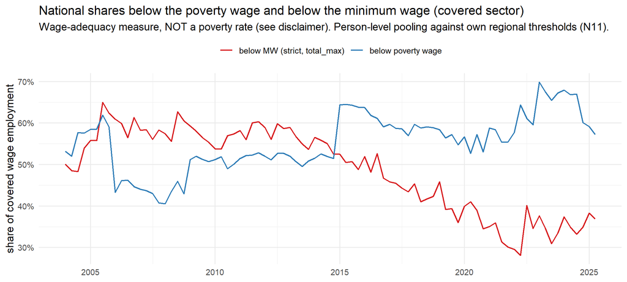

```r
bind_nat %>%
  select(ref_date, `below poverty wage` = below_pt,
         `below MW (strict, total_max)` = B_max) %>%
  pivot_longer(-ref_date) %>%
  ggplot(aes(ref_date, value, colour = name)) +
  geom_line(linewidth = 0.7) +
  scale_y_continuous(labels = percent_format()) +
  scale_colour_manual(values = c("#d7191c", "#2c7bb6")) +
  labs(title = "National shares below the poverty wage and below the minimum wage (covered sector)",
       subtitle = "Wage-adequacy measure, NOT a poverty rate (see disclaimer). Person-level pooling against own regional thresholds (N11).",
       x = NULL, y = "share of covered wage employment", colour = NULL) +
  theme(legend.position = "top")
```

```r
# Divisor sensitivity (N9): factor-days 313 (headline) vs calendar 365.
# The two differ by the fixed ratio 365/313 = 1.166; the table shows the
# effect on the latest-quarter national share below the poverty wage.
alt <- sample_C %>%
  filter(ref_date == max(ref_date)) %>%
  summarise(
    `share below PT (313 factor days)` = wshare(basic_pay_php < pt_wage_m, weight),
    `share below PT (365 calendar days)` = wshare(basic_pay_php < pt_wage_m_365, weight),
    `share below PT (linear interpolation)` = wshare(basic_pay_php < pt_wage_linear, weight))
latest_d <- max(sample_C$ref_date)
kt(alt, sprintf("Poverty-wage sensitivity, latest quarter (%d Q%d): divisor convention and projection method",
                year(latest_d), quarter(latest_d)), digits = 3)
```

Poverty-wage sensitivity, latest quarter (2025 Q2): divisor convention and projection method

| share below PT (313 factor days) | share below PT (365 calendar days) | share below PT (linear interpolation) |
| --- | --- | --- |
| 0.572 | 0.359 | NA |

# 11 Heaping Diagnostics

**Formula (N12).** $H_d = \Pr_\omega[w_i \bmod d = 0]$, weighted, Sample C. Heaping is the identification threat for bunching: a spike at a round MW is confounded with round-number reporting; a spike at an off-round MW is not.

```r
heap_period <- sample_C %>%
  mutate(subper = paste0(floor(year / 5) * 5, "-", floor(year / 5) * 5 + 4)) %>%
  group_by(subper) %>%
  summarise(
    div_5   = 100 * wshare(basic_pay_php %% 5   == 0, weight),   # (N12), d = 5
    div_10  = 100 * wshare(basic_pay_php %% 10  == 0, weight),   # d = 10
    div_50  = 100 * wshare(basic_pay_php %% 50  == 0, weight),   # d = 50
    div_100 = 100 * wshare(basic_pay_php %% 100 == 0, weight),   # d = 100
    n = n(), .groups = "drop")
kt(heap_period, "Weighted share of wage reports divisible by 5 / 10 / 50 / 100 PHP, by 5-year subperiod (Sample C, national)", digits = 1)
```

Weighted share of wage reports divisible by 5 / 10 / 50 / 100 PHP, by 5-year subperiod (Sample C, national)

| subper | div_5 | div_10 | div_50 | div_100 | n |
| --- | --- | --- | --- | --- | --- |
| 2000-2004 | 77.6 | 70.1 | 48.7 | 28.3 | 80665 |
| 2005-2009 | 73.2 | 64.3 | 46.9 | 26.2 | 364276 |
| 2010-2014 | 67.8 | 59.6 | 46.3 | 27.1 | 414268 |
| 2015-2019 | 70.5 | 65.1 | 54.3 | 34.9 | 473510 |
| 2020-2024 | 79.8 | 74.6 | 63.3 | 46.1 | 788023 |
| 2025-2029 | 86.6 | 76.7 | 66.0 | 50.3 | 49299 |

```r
sample_C %>%
  group_by(region_wb) %>%
  summarise(div_50  = 100 * wshare(basic_pay_php %% 50 == 0, weight),
            div_100 = 100 * wshare(basic_pay_php %% 100 == 0, weight),
            .groups = "drop") %>%
  kt("Heaping by lineage, pooled (divisible by 50 / by 100, weighted %)", digits = 1)
```

Heaping by lineage, pooled (divisible by 50 / by 100, weighted %)

| region_wb | div_50 | div_100 |
| --- | --- | --- |
| NCR | 46.8 | 33.6 |
| CAR | 65.1 | 42.3 |
| I | 64.7 | 38.8 |
| II | 64.9 | 39.2 |
| III | 65.1 | 44.8 |
| IV-A | 49.7 | 34.0 |
| IV-B | 63.3 | 38.4 |
| V | 61.6 | 36.9 |
| VI | 55.9 | 32.7 |
| VII | 48.5 | 30.7 |
| VIII | 61.7 | 36.6 |
| IX | 57.3 | 33.9 |
| X | 53.3 | 31.7 |
| XI | 54.1 | 33.4 |
| XII | 50.0 | 30.0 |
| XIII | 57.6 | 35.2 |
| ARMM-BARMM | 70.8 | 40.9 |

## 11.1 Wage-order roundness by lineage

```r
# An order is "off-round" if its total_max is NOT divisible by 50 -- at such
# rates, digit heaping cannot mechanically manufacture a spike at the floor.
roundness <- mw_lineage %>%
  filter(effectivity_date >= as.Date("2004-01-01")) %>%
  mutate(round50 = total_max %% 50 == 0) %>%
  group_by(region_wb) %>%
  summarise(n_orders = n(), n_round50 = sum(round50),
            pct_off_round = 100 * mean(!round50), .groups = "drop")
kt(roundness, "In-sample wage-order rows (2004+) by lineage: how many set round (divisible-by-50) total_max rates. Off-round region-quarters are the clean-identification subset for bunching.", digits = 0)
```

In-sample wage-order rows (2004+) by lineage: how many set round (divisible-by-50) total_max rates. Off-round region-quarters are the clean-identification subset for bunching.

| region_wb | n_orders | n_round50 | pct_off_round |
| --- | --- | --- | --- |
| NCR | 22 | 2 | 91 |
| CAR | 18 | 3 | 83 |
| I | 20 | 3 | 85 |
| II | 18 | 4 | 78 |
| III | 24 | 6 | 75 |
| IV-A | 21 | 4 | 81 |
| IV-B | 20 | 2 | 90 |
| V | 22 | 0 | 100 |
| VI | 20 | 4 | 80 |
| VII | 18 | 1 | 94 |
| VIII | 20 | 1 | 95 |
| IX | 19 | 1 | 95 |
| X | 21 | 1 | 95 |
| XI | 23 | 1 | 96 |
| XII | 22 | 2 | 91 |
| XIII | 23 | 4 | 83 |
| ARMM-BARMM | 15 | 3 | 80 |

```r
# Region-quarter flag used in the off-round bunching split
qtr_round <- qtr_grid %>%
  transmute(region_wb, ref_date, mw_round50 = mw_tot_max %% 50 == 0)
```

# 12 Bunching at the Floor

## 12.1 Pooled log-distance histogram

**Formula (N7).** Weighted share per 0.025-log-point bin of $\log w_i - \log MW_{r(i)}(d_{t(i)})$, each worker against their **own** contemporaneous regional floor; pooled across all lineages and quarters, then also faceted by lineage.

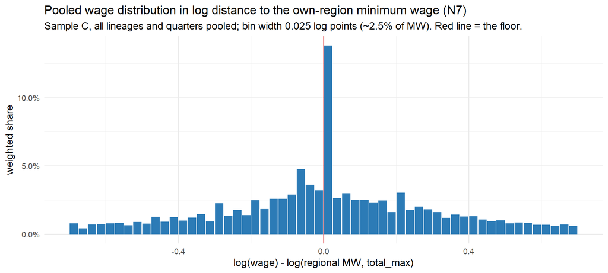

```r
bunch <- sample_C %>%
  mutate(logdist = log(basic_pay_php) - log(mw_tot_max)) %>%
  filter(abs(logdist) <= LOG_BIN_LIM) %>%
  mutate(bin = floor(logdist / LOG_BIN_H) * LOG_BIN_H)

bunch_nat <- bunch %>%
  group_by(bin) %>% summarise(w = sum(weight), .groups = "drop") %>%
  mutate(share = w / sum(w))

ggplot(bunch_nat, aes(bin + LOG_BIN_H / 2, share)) +
  geom_col(fill = "#2c7bb6", width = LOG_BIN_H * 0.92) +
  geom_vline(xintercept = 0, colour = "#d7191c", linewidth = 0.6) +
  scale_y_continuous(labels = percent_format(accuracy = 0.1)) +
  labs(title = "Pooled wage distribution in log distance to the own-region minimum wage (N7)",
       subtitle = sprintf("Sample C, all lineages and quarters pooled; bin width %.3f log points (~%.1f%% of MW). Red line = the floor.", LOG_BIN_H, 100 * LOG_BIN_H),
       x = "log(wage) - log(regional MW, total_max)", y = "weighted share")
```

**Reading.** The pooled distribution shows visible mass concentration at and just below each worker’s own contemporaneous floor (the red line), with the sub-floor shoulder confirming that the floor truncates pay-setting imperfectly. Some of the spike at zero is genuine floor-referenced pay-setting and some is round-number reporting landing on round wage orders — the heaping section and the off-round split below exist precisely because this chart alone cannot separate the two.

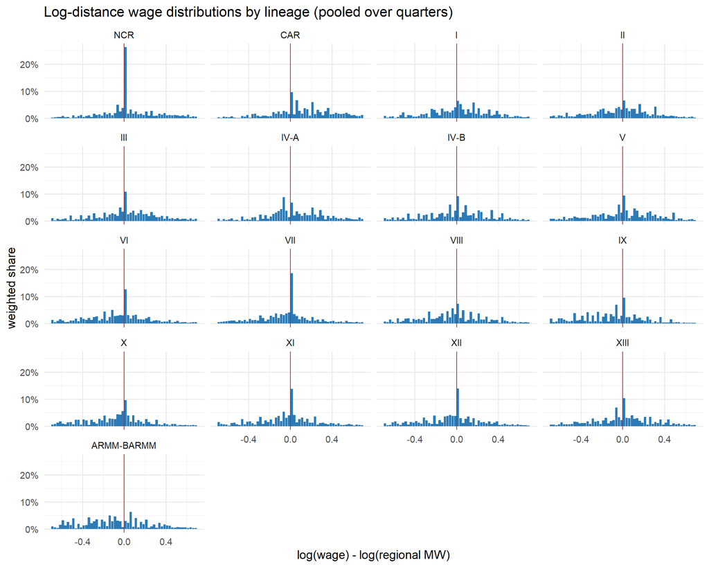

```r
bunch %>%
  group_by(region_wb, bin) %>% summarise(w = sum(weight), .groups = "drop") %>%
  group_by(region_wb) %>% mutate(share = w / sum(w)) %>% ungroup() %>%
  ggplot(aes(bin + LOG_BIN_H / 2, share)) +
  geom_col(fill = "#2c7bb6", width = LOG_BIN_H * 0.92) +
  geom_vline(xintercept = 0, colour = "#d7191c", linewidth = 0.4) +
  facet_wrap(~region_wb, ncol = 4) +
  scale_y_continuous(labels = percent_format(accuracy = 1)) +
  labs(title = "Log-distance wage distributions by lineage (pooled over quarters)",
       x = "log(wage) - log(regional MW)", y = "weighted share")
```

## 12.2 Off-round vs. round region-quarters

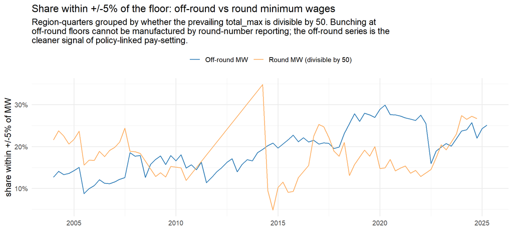

```r
# At-band share (N6, +/-5%) over time, splitting region-quarters by whether
# the prevailing total_max is divisible by 50. If the at-MW spike were pure
# digit heaping, the off-round series would sit near zero.
at_by_round <- sample_C %>%
  left_join(qtr_round, by = c("region_wb", "ref_date")) %>%
  mutate(grp = if_else(mw_round50, "Round MW (divisible by 50)",
                       "Off-round MW")) %>%
  group_by(ref_date, grp) %>%
  summarise(at5 = wshare(abs(basic_pay_php / mw_tot_max - 1) <= AT_MW_BAND_PCT,
                         weight), .groups = "drop")

ggplot(at_by_round, aes(ref_date, at5, colour = grp)) +
  geom_line(linewidth = 0.6) +
  scale_y_continuous(labels = percent_format()) +
  scale_colour_manual(values = c("Off-round MW" = "#2c7bb6",
                                 "Round MW (divisible by 50)" = "#fdae61")) +
  labs(title = "Share within +/-5% of the floor: off-round vs round minimum wages",
       subtitle = wrap_text("Region-quarters grouped by whether the prevailing total_max is divisible by 50. Bunching at off-round floors cannot be manufactured by round-number reporting; the off-round series is the cleaner signal of policy-linked pay-setting."),
       x = NULL, y = "share within +/-5% of MW", colour = NULL) +
  theme(legend.position = "top")
```

**Reading.** This is the cleanest evidence that bunching is real: in region-quarters where the prevailing floor is *not* a round number, 25% of covered workers still sit within ±5% of it in the latest quarter. Digit heaping cannot manufacture a spike at ₱517; only pay-setting that references the wage order can. The gap between the two lines bounds how much of the round-MW at-share is a reporting artifact.

# 13 The Region × Quarter × ₱25 Wage-Bin Panel (Saved Artifact)

**Formula (N8).** Left-closed ₱25 bins of $(w_i - MW^{tot,max}_{r}(d_t))$ in **nominal pesos**, from −300 to +600; per $(r, t, b)$ the panel stores the unweighted count, summed weight, and weighted within-cell share. This is design (a) of the PoC’s feasibility matrix — the input any stacked-DiD / event-study analysis would consume — saved to `Output/`.

```r
bin_breaks <- seq(BIN_LO, BIN_HI + BIN_PHP, by = BIN_PHP)

bin_panel <- sample_C %>%
  mutate(rel = basic_pay_php - mw_tot_max,
         bin = if_else(rel >= BIN_LO & rel < BIN_HI + BIN_PHP,
                       floor(rel / BIN_PHP) * BIN_PHP, NA_real_)) %>%
  filter(!is.na(bin)) %>%
  group_by(region_wb, year, quarter, ref_date, mw_tot_max, bin) %>%
  summarise(n_unwt = n(), w_sum = sum(weight), .groups = "drop") %>%
  group_by(region_wb, ref_date) %>%
  mutate(share_wt = w_sum / sum(w_sum)) %>%
  ungroup() %>%
  # complete the grid so zero-mass bins exist explicitly (a Cengiz-style
  # averaging requirement flagged in the PoC)
  complete(nesting(region_wb, year, quarter, ref_date, mw_tot_max),
           bin = head(bin_breaks, -1),
           fill = list(n_unwt = 0L, w_sum = 0, share_wt = 0))

write_rds(bin_panel, "Output/wage_bin_panel_region_quarter.rds")
write_csv(bin_panel, "Output/wage_bin_panel_region_quarter.csv")
cat("Saved wage-bin panel:",
    comma(nrow(bin_panel)), "rows (",
    n_distinct(bin_panel$region_wb), "lineages x",
    n_distinct(bin_panel$ref_date), "quarters x",
    length(bin_breaks) - 1, "bins )\n")
```

```
## Saved wage-bin panel: 54,057 rows ( 17 lineages x 86 quarters x 37 bins )
```

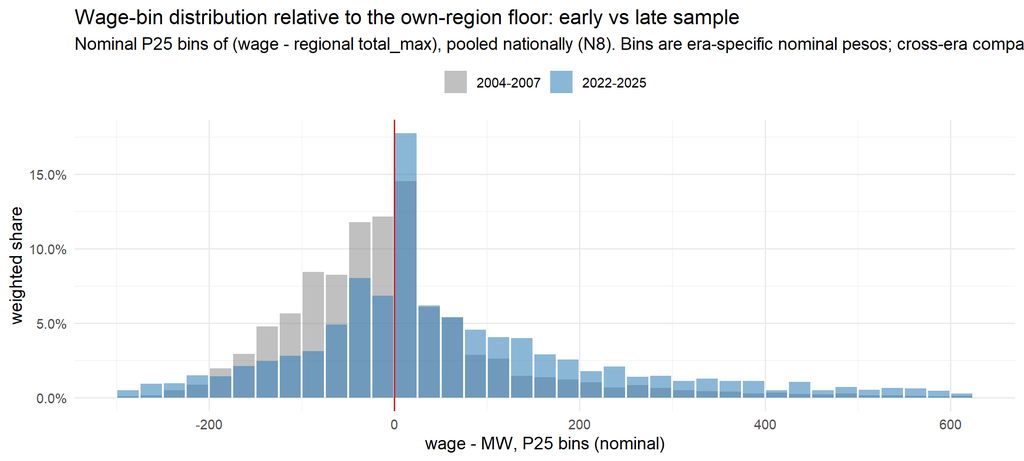

```r
# Preview: national average bin shares, first 4 vs latest 4 sample years.
bin_panel %>%
  mutate(era = case_when(year <= 2007 ~ "2004-2007",
                         year >= 2022 ~ "2022-2025",
                         TRUE ~ NA_character_)) %>%
  filter(!is.na(era)) %>%
  group_by(era, bin) %>%
  summarise(w = sum(w_sum), .groups = "drop") %>%
  group_by(era) %>% mutate(share = w / sum(w)) %>% ungroup() %>%
  ggplot(aes(bin + BIN_PHP / 2, share, fill = era)) +
  geom_col(position = "identity", alpha = 0.55, width = BIN_PHP * 0.92) +
  geom_vline(xintercept = 0, colour = "#d7191c", linewidth = 0.6) +
  scale_fill_manual(values = c("2004-2007" = "grey55", "2022-2025" = "#2c7bb6")) +
  scale_y_continuous(labels = percent_format(accuracy = 0.5)) +
  labs(title = "Wage-bin distribution relative to the own-region floor: early vs late sample",
       subtitle = sprintf("Nominal P%d bins of (wage - regional total_max), pooled nationally (N8). Bins are era-specific nominal pesos; cross-era comparison is of SHAPE around the floor, not of levels.", BIN_PHP),
       x = sprintf("wage - MW, P%d bins (nominal)", BIN_PHP),
       y = "weighted share", fill = NULL) +
  theme(legend.position = "top")
```

**Reading.** Compare shapes, not positions: each era’s bins are its own nominal pesos, so the only valid takeaway is how the distribution organises itself *around the floor* — the spike at [0, 25) and the depth of the sub-floor shoulder — early versus late in the sample. For level-comparable versions of this picture, the spatially-indexed real bins in the next subsection are the right object.

## 13.1 Spatially Comparable Real Wage Bins (N13): MW-Anchored, Nationally Summable

The nominal MW-relative bins above cannot be summed across regions or years, and — the sharper problem this document must solve — neither can naive “real 2018 PHP” bins: the CPI indexes each region over *time*, but a real ₱25 in NCR is not the purchasing power of a real ₱25 in BARMM. Per (N13), the 2018 poverty thresholds supply the missing **cross-region price-level index** $\theta_r$; wages and floors are put in NCR-2018-equivalent pesos ($\tilde w = w^{real}/\theta_r$, $\tilde M = MW^{real}/\theta_r$) and binned in ₱25 steps of $\tilde w - \tilde M$ — distance from the **real minimum wage** on one common scale. In NCR ($\theta = 1$) this is exactly the PoC construction.

```r
# (N13): bin b (left-closed, P25) holds i iff
#           b <= (real_pay_i - real_mw_i) / theta_r < b + 25,
# real_pay = w/defl, real_mw = MW^{tot,max}/defl (N3), theta_r from the
# 2018 poverty thresholds. Unit: NCR-2018-equivalent pesos.
bin_real_obs <- sample_C %>%
  mutate(real_pay = basic_pay_php / defl,
         real_mw  = mw_tot_max / defl,
         rel_s    = (real_pay - real_mw) / theta,
         in_range = rel_s >= BIN_REAL_LO & rel_s < BIN_REAL_HI + BIN_PHP,
         bin      = if_else(in_range, floor(rel_s / BIN_PHP) * BIN_PHP, NA_real_))

cat(sprintf("Share of Sample C outside the [%d, %d) NCR-2018-equivalent range: %.2f%% (weighted)\n",
            BIN_REAL_LO, BIN_REAL_HI + BIN_PHP,
            100 * wshare(!bin_real_obs$in_range, bin_real_obs$weight)))
```

```
## Share of Sample C outside the [-300, 625) NCR-2018-equivalent range: 5.72% (weighted)
```

```r
bin_real_breaks <- seq(BIN_REAL_LO, BIN_REAL_HI, by = BIN_PHP)

bin_panel_real <- bin_real_obs %>%
  filter(in_range) %>%
  group_by(region_wb, year, quarter, ref_date, bin) %>%
  summarise(n_unwt = n(), w_sum = sum(weight), .groups = "drop") %>%
  group_by(region_wb, ref_date) %>%
  mutate(share_wt = w_sum / sum(w_sum)) %>%
  ungroup() %>%
  complete(nesting(region_wb, year, quarter, ref_date),
           bin = bin_real_breaks,
           fill = list(n_unwt = 0L, w_sum = 0, share_wt = 0)) %>%
  left_join(theta_tbl, by = "region_wb")

write_rds(bin_panel_real, "Output/wage_bin_panel_real_spatial.rds")
write_csv(bin_panel_real, "Output/wage_bin_panel_real_spatial.csv")
cat("Saved spatially-indexed real bin panel:", comma(nrow(bin_panel_real)), "rows\n")
```

```
## Saved spatially-indexed real bin panel: 54,057 rows
```

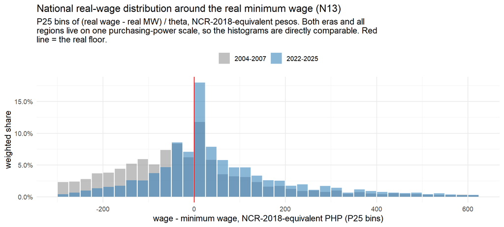

```r
# National summation (N13): weighted mass per bin summed over ALL regions
# and quarters within each era -- legitimate because every term is in
# NCR-2018-equivalent pesos measured from its own regional real floor.
bin_panel_real %>%
  mutate(era = case_when(year <= 2007 ~ "2004-2007",
                         year >= 2022 ~ "2022-2025",
                         TRUE ~ NA_character_)) %>%
  filter(!is.na(era)) %>%
  group_by(era, bin) %>%
  summarise(w = sum(w_sum), .groups = "drop") %>%
  group_by(era) %>% mutate(share = w / sum(w)) %>% ungroup() %>%
  ggplot(aes(bin + BIN_PHP / 2, share, fill = era)) +
  geom_col(position = "identity", alpha = 0.55, width = BIN_PHP * 0.92) +
  geom_vline(xintercept = 0, colour = "#d7191c", linewidth = 0.6) +
  scale_fill_manual(values = c("2004-2007" = "grey55", "2022-2025" = "#2c7bb6")) +
  scale_y_continuous(labels = percent_format(accuracy = 0.5)) +
  labs(title = "National real-wage distribution around the real minimum wage (N13)",
       subtitle = wrap_text("P25 bins of (real wage - real MW) / theta, NCR-2018-equivalent pesos. Both eras and all regions live on one purchasing-power scale, so the histograms are directly comparable. Red line = the real floor."),
       x = "wage - minimum wage, NCR-2018-equivalent PHP (P25 bins)",
       y = "weighted share", fill = NULL) +
  theme(legend.position = "top")
```

**Reading.** With both eras on one purchasing-power scale, two facts coexist: the at-floor spike persists across two decades, and the sub-floor share of in-range mass moved from 57% (2004–07) to 36% (2022–25). This chart describes where the covered workforce sits relative to its floors; it cannot attribute the change to policy, growth, or composition.

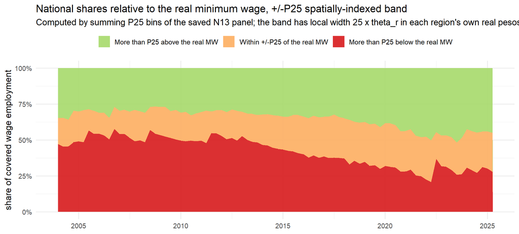

```r
# "Any band is a sum of bins": the +/-P25 spatially-indexed band around the
# real MW is exactly bins -25 and 0; below-band = all b < -25. National
# time series computed purely from the saved panel. (The continuous
# analogue at_real25s in bind_nat differs only by bin discretisation.)
bin_panel_real %>%
  group_by(ref_date, band = case_when(
    bin < -BIN_PHP ~ "More than P25 below the real MW",
    bin %in% c(-BIN_PHP, 0) ~ "Within +/-P25 of the real MW",
    TRUE ~ "More than P25 above the real MW")) %>%
  summarise(w = sum(w_sum), .groups = "drop") %>%
  group_by(ref_date) %>% mutate(share = w / sum(w)) %>% ungroup() %>%
  mutate(band = factor(band, levels = c("More than P25 above the real MW",
                                        "Within +/-P25 of the real MW",
                                        "More than P25 below the real MW"))) %>%
  ggplot(aes(ref_date, share, fill = band)) +
  geom_area(alpha = 0.9) +
  scale_fill_manual(values = c("#a6d96a", "#fdae61", "#d7191c")) +
  scale_y_continuous(labels = percent_format()) +
  labs(title = "National shares relative to the real minimum wage, +/-P25 spatially-indexed band",
       subtitle = "Computed by summing P25 bins of the saved N13 panel; the band has local width 25 x theta_r in each region's own real pesos.",
       x = NULL, y = "share of covered wage employment", fill = NULL) +
  theme(legend.position = "top")
```

**Reading.** The stacked view turns the saved panel into a running answer to “how is the covered workforce distributed around the real floor?” — currently 27% within the spatially-indexed ±₱25 band. Because every band is literally a sum of saved bins, any alternative band a policy discussion needs can be recomputed from the artifact without touching microdata.

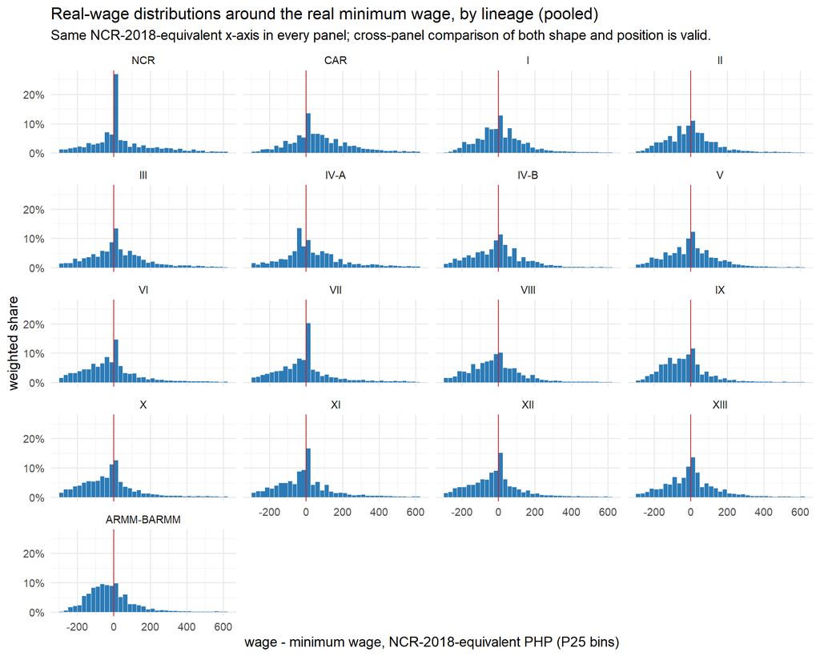

```r
bin_panel_real %>%
  group_by(region_wb, bin) %>%
  summarise(w = sum(w_sum), .groups = "drop") %>%
  group_by(region_wb) %>% mutate(share = w / sum(w)) %>% ungroup() %>%
  ggplot(aes(bin + BIN_PHP / 2, share)) +
  geom_col(fill = "#2c7bb6", width = BIN_PHP * 0.92) +
  geom_vline(xintercept = 0, colour = "#d7191c", linewidth = 0.4) +
  facet_wrap(~region_wb, ncol = 4) +
  scale_y_continuous(labels = percent_format(accuracy = 1)) +
  labs(title = "Real-wage distributions around the real minimum wage, by lineage (pooled)",
       subtitle = "Same NCR-2018-equivalent x-axis in every panel; cross-panel comparison of both shape and position is valid.",
       x = "wage - minimum wage, NCR-2018-equivalent PHP (P25 bins)",
       y = "weighted share")
```

**Reading.** This is the one histogram grid where cross-panel *position* comparisons are legitimate: every axis is NCR-2018-equivalent pesos from the region’s own real floor. Panels with heavier left-of-zero mass are regions where the floor overshoots more of its covered distribution; panels with mass concentrated just right of zero are regions where the floor effectively *is* the going wage. That cross-region variation in bite is exactly what the event study exploits.

# 14 The Wage-Increase Event Study (Cengiz-Style)

This section carries the NCR PoC’s event-time wage-bin analysis to its national form, per (N14), with three upgrades the PoC’s feasibility section anticipated: **per-capita bin employment** instead of shares (shares can only show redistribution; employment impact requires counts against a population denominator), **spatially comparable bins** (N13, so events in different regions average meaningfully), and — the step NCR alone could never take — **timing-based control regions**: lineages with no wage order of their own within ±4 quarters of the event, binned against the *treated* event’s real floor. The honest framing stands: controls are selected on wage-order timing, not random assignment, and no never-treated region exists; this is the closest feasible approximation to Cengiz et al. (2019), not a replication of their identification.

## 14.1 How the Event–Bin Panel Is Built (and Why It Has To Be Built This Way)

The LFS is a **repeated cross-section**: different people every quarter, no worker identifiers, no way to follow anyone. That rules out every person-level design (“did worker $i$ keep their job?”). The Cengiz et al. insight is that the panel unit does not have to be the worker: make it the **wage bin**. A ₱25 slice of the wage distribution in a given region *is* followable over time — its employment mass is estimable from every cross-section — and the question “where did the sub-floor jobs go?” becomes an accounting identity over bins. Concretely, the pipeline is:

1. **Person-quarter observations** (Sample C: private-establishment, non-agriculture wage workers with positive daily basic pay) carry a wage, a weight, a lineage, and a quarter. Nothing else about the worker is needed.
2. **Common real scale (N13).** Each wage is deflated by its own region’s CPI to 2018 pesos, then divided by $\theta_r$ (2018 poverty-threshold ratio to NCR). Without this step, a “₱25 bin” is a different object in every region and stacking events across regions would add apples to carabaos.
3. **Events (N2 → N14).** A wage order enters the analysis on the first LFS round whose reference date is on/after its effectivity (the as-of join), provided the nominal increase is ≥ 3%. The new floor is frozen in the same common unit: $\tilde M_e = MW^{new} / (\text{defl}_{r,m(t_0)}\,\theta_r)$. Multi-tranche orders appear as separate candidate events per tranche (small tranches usually fail the ≥ 3% screen).
4. **Windows in event time.** Each event contributes quarters $\tau = -4 \dots +7$; post-side quarters at/after the lineage’s *next* order are censored (they belong to the next event’s story).
5. **Binning.** Every person-quarter in a window is assigned to the ₱25 bin of $\tilde w_i - \tilde M_e$ — distance from *that event’s* frozen real floor, including in pre-period quarters (where the floor is not yet in force; bins are a fixed ruler, not the prevailing law).
6. **Collapse to the panel.** Summing weights within (event, unit, τ, bin) and dividing by the unit’s working-age population WAP$_{r,t}$ gives per-capita bin employment $E_{e,\tau,b}$ — the panel outcome. Zero-mass bins are materialised explicitly (`complete()`), because “no one is paid here anymore” is exactly the signal of interest.
7. **Demeaning.** Subtracting each (event, unit, bin)’s own pre-window mean gives $\Delta E$: how far this bin’s employment sits from *its own* pre-order level.
8. **Stacking.** $\Delta E$ profiles are averaged across events with equal weights — the same LFS quarter can legitimately serve several overlapping event windows (and treated/control roles for different events); stacking is precisely this reuse, aligned on event time.

**Why per-capita counts and not shares.** The PoC used within-quarter employment *shares* per bin; shares always sum to one, so they can only ever show *redistribution* across bins. Dividing by working-age population instead lets total covered employment move: if sub-floor jobs vanish without reappearing above the floor, per-capita bin masses record it and the cumulative sum ends below zero. That is the entire difference between “the distribution changed shape” and “employment changed.”

**What the DiD adds, exactly.** The raw stacked contrast (post-mean minus pre-mean) answers: *how did the treated region’s wage distribution evolve across the order?* Anything else moving at the same time — inflation mechanically pushing nominal wages across a fixed real ruler, seasonal hiring, macro shocks — is absorbed into the answer. The DiD subtracts the same pre/post contrast computed in **control lineages**: regions with no wage order of their own within ±4 quarters, whose workers are binned against the *treated* event’s floor $\tilde M_e$ (a coherent operation only because step 2 put everyone on one scale). Whatever moves wage distributions *everywhere* — national inflation surprises, seasonality, common growth — differences out; what survives is the treated-minus-control difference in distributional change around the floor.

**Is that causal?** Under the textbook parallel-trends assumption — absent the wage order, the treated region’s binned distribution would have evolved like the controls’ — the DiD identifies the causal effect of the order on bin employment. That assumption is **not credible enough here to claim causality**, for reasons the Threats subsection makes specific: control regions exist mainly because their boards *chose* to freeze (choices concentrated in crises), treated boards chose to raise, and both choices respond to regional conditions. The defensible reading: the raw estimates are descriptive accounting; the DiD estimates are a **materially better-adjusted description** that nets out common shocks; neither is a randomized experiment, and the pre-trend profile plus the upper-tail placebo are the evidence for how far short of causal each falls in practice.

```r
# (N14) Events from the assigned-rate grid (N2): quarters where mw_tot_max
# rises, screen inc_pct >= EVENT_MIN_NOM_PCT. Contamination calendar (for
# control selection) uses ALL increases, screened or not: any wage order
# moves a would-be control's own floor.
qtr_idx <- qtr_grid %>%
  group_by(region_wb) %>% arrange(ref_date, .by_group = TRUE) %>%
  mutate(qidx = row_number()) %>% ungroup()

all_increases <- qtr_idx %>%
  group_by(region_wb) %>% arrange(qidx, .by_group = TRUE) %>%
  mutate(mw_prev = lag(mw_tot_max)) %>%
  filter(!is.na(mw_prev), mw_tot_max > mw_prev) %>%
  ungroup() %>%
  select(region_wb, qidx, mw_prev, mw_tot_max, ref_date)

events <- all_increases %>%
  group_by(region_wb) %>% arrange(qidx, .by_group = TRUE) %>%
  mutate(inc_pct = mw_tot_max / mw_prev - 1,
         next_event_qidx = coalesce(lead(qidx), Inf)) %>%
  ungroup() %>%
  filter(inc_pct >= EVENT_MIN_NOM_PCT) %>%
  transmute(event_id = paste0(region_wb, "_", format(ref_date, "%Y%m")),
            region_wb, t0_qidx = qidx, t0_date = ref_date,
            mw_new = mw_tot_max, mw_prev, inc_pct, next_event_qidx)

# Real, spatially indexed event floor (N14): M_e = mw_new / (defl * theta)
events <- events %>%
  left_join(cpi_defl %>% select(region_wb, cpi_month, defl),
            by = c("region_wb", "t0_date" = "cpi_month")) %>%
  left_join(theta_tbl, by = "region_wb") %>%
  mutate(M_e = mw_new / (defl * theta)) %>%
  select(-defl, -theta)

n_qtrs <- max(qtr_idx$qidx)
events <- events %>%
  mutate(has_pre  = t0_qidx - EVENT_PRE_Q >= 1,
         has_post = t0_qidx + 3 <= n_qtrs & t0_qidx + 3 < next_event_qidx)

# Clean controls per event: lineages with NO increase (of any size) in
# calendar quarters [t0-4, t0+4].
ctrl_pairs <- events %>%
  select(event_id, region_wb, t0_qidx) %>%
  mutate(win_lo = t0_qidx - 4L, win_hi = t0_qidx + 4L) %>%
  crossing(ctrl_wb = factor(REGION_ORDER, levels = REGION_ORDER)) %>%
  filter(ctrl_wb != region_wb) %>%
  anti_join(all_increases %>% select(ctrl_wb = region_wb, c_qidx = qidx),
            by = join_by(ctrl_wb, between(y$c_qidx, x$win_lo, x$win_hi))) %>%
  select(event_id, ctrl_wb)

events <- events %>%
  left_join(ctrl_pairs %>% count(event_id, name = "n_controls"),
            by = "event_id") %>%
  mutate(n_controls = coalesce(n_controls, 0L),
         did_ok = has_pre & has_post & n_controls >= MIN_CONTROLS)

cat("Candidate increases >=", 100 * EVENT_MIN_NOM_PCT, "%:", nrow(events),
    "\n  with full [-4,-1] pre-window:", sum(events$has_pre),
    "\n  also uncensored through tau=+3 (headline set):",
    sum(events$has_pre & events$has_post),
    "\n  additionally with >=", MIN_CONTROLS, "clean controls (DiD set):",
    sum(events$did_ok), "\n")
```

```
## Candidate increases >= 3 %: 232
##   with full [-4,-1] pre-window: 221
##   also uncensored through tau=+3 (headline set): 158
##   additionally with >= 3 clean controls (DiD set): 11
```

```r
events %>%
  filter(has_pre) %>%
  group_by(region_wb) %>%
  summarise(n_events = n(), median_inc_pct = 100 * median(inc_pct),
            n_headline = sum(has_post), n_did = sum(did_ok),
            .groups = "drop") %>%
  kt("Events by lineage: clean pre-window; headline subset (uncensored through tau=+3); DiD subset (headline + >= 3 timing-based clean controls)", digits = 1)
```

Events by lineage: clean pre-window; headline subset (uncensored through tau=+3); DiD subset (headline + >= 3 timing-based clean controls)

| region_wb | n_events | median_inc_pct | n_headline | n_did |
| --- | --- | --- | --- | --- |
| NCR | 13 | 5.5 | 10 | 1 |
| CAR | 12 | 6.4 | 9 | 0 |
| I | 12 | 7.8 | 9 | 0 |
| II | 13 | 5.4 | 9 | 0 |
| III | 13 | 5.0 | 9 | 1 |
| IV-A | 15 | 5.3 | 8 | 1 |
| IV-B | 11 | 6.3 | 7 | 0 |
| V | 10 | 5.8 | 8 | 1 |
| VI | 14 | 6.8 | 13 | 2 |
| VII | 15 | 6.8 | 13 | 2 |
| VIII | 13 | 5.6 | 7 | 1 |
| IX | 12 | 6.7 | 10 | 0 |
| X | 14 | 6.0 | 10 | 0 |
| XI | 16 | 6.5 | 8 | 0 |
| XII | 13 | 5.2 | 9 | 1 |
| XIII | 13 | 5.7 | 8 | 0 |
| ARMM-BARMM | 12 | 5.8 | 11 | 1 |

```r
# Working-age population denominator (all persons 15-64, employed or not)
wap <- lfs %>%
  filter(age_years >= 15, age_years <= 64, !is.na(weight), weight > 0) %>%
  group_by(region_wb, ref_date) %>%
  summarise(wap = sum(weight), .groups = "drop")

# Spatially indexed real wages once, reused for treated and control roles
obs_s <- sample_C %>%
  mutate(w_tilde = basic_pay_php / (defl * theta)) %>%
  select(region_wb, ref_date, w_tilde, weight)

# Event x tau x unit frame. Treated unit: the event's own lineage over
# tau in [-4, +7] (post censored at its next event). Control units: clean
# lineages over tau in [-4, +3] (their own floors are event-free on
# [t0-4, t0+4] by construction, which covers exactly this window).
evt_units <- bind_rows(
  events %>% filter(has_pre) %>%
    transmute(event_id, unit_wb = region_wb, role = "treat",
              t0_qidx, next_event_qidx, M_e),
  events %>% filter(has_pre) %>%
    inner_join(ctrl_pairs, by = "event_id") %>%
    transmute(event_id, unit_wb = ctrl_wb, role = "ctrl",
              t0_qidx, next_event_qidx = Inf, M_e)
)

evt_tau <- evt_units %>%
  crossing(tau = -EVENT_PRE_Q:EVENT_POST_Q) %>%
  filter(role == "treat" | tau <= 3) %>%
  mutate(target_qidx = t0_qidx + tau) %>%
  filter(target_qidx >= 1, target_qidx <= n_qtrs,
         tau < 0 | target_qidx < next_event_qidx) %>%
  left_join(qtr_idx %>% select(unit_wb = region_wb, qidx,
                               target_date = ref_date),
            by = c("unit_wb", "target_qidx" = "qidx"))

# Per-capita bin masses (N14): E = sum(weight in bin) / WAP(unit, quarter),
# bins of (w_tilde - M_e), P25, [-300, 600).
evt_bins_breaks <- seq(EVENT_BIN_LO, EVENT_BIN_HI, by = BIN_PHP)

evt_E <- obs_s %>%
  inner_join(evt_tau %>% select(event_id, role, unit_wb, target_date, tau, M_e),
             by = c("region_wb" = "unit_wb", "ref_date" = "target_date"),
             relationship = "many-to-many") %>%
  mutate(rel = w_tilde - M_e,
         bin = if_else(rel >= EVENT_BIN_LO & rel < EVENT_BIN_HI + BIN_PHP,
                       floor(rel / BIN_PHP) * BIN_PHP, NA_real_)) %>%
  filter(!is.na(bin)) %>%
  group_by(event_id, role, region_wb, tau, ref_date, bin) %>%
  summarise(w_sum = sum(weight), n_unwt = n(), .groups = "drop") %>%
  complete(nesting(event_id, role, region_wb, tau, ref_date),
           bin = evt_bins_breaks, fill = list(w_sum = 0, n_unwt = 0L)) %>%
  left_join(wap, by = c("region_wb", "ref_date")) %>%
  mutate(E = w_sum / wap)

# Delta E per (event, unit, bin): subtract the unit's own pre-window mean
evt_dE <- evt_E %>%
  group_by(event_id, role, region_wb, bin) %>%
  mutate(E_pre = mean(E[tau < 0])) %>%
  ungroup() %>%
  mutate(dE = E - E_pre)

# DiD per (event, tau, bin): treated minus equal-weighted control mean
evt_did <- evt_dE %>%
  group_by(event_id, tau, bin, role) %>%
  summarise(dE = mean(dE), .groups = "drop") %>%   # ctrl mean; treat = itself
  pivot_wider(names_from = role, values_from = dE) %>%
  filter(!is.na(treat), !is.na(ctrl)) %>%
  mutate(dE_did = treat - ctrl)
```

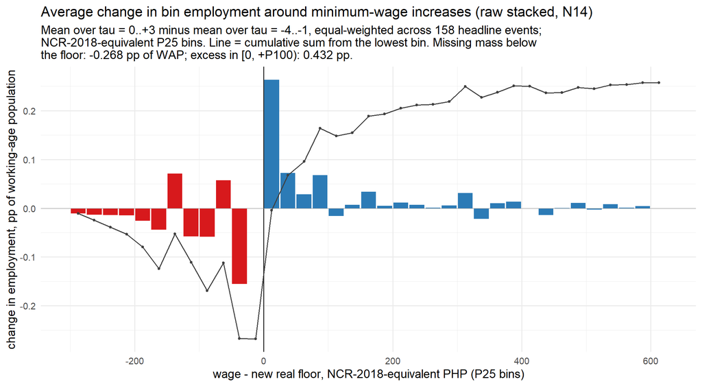

```r
# Headline Cengiz figure (raw stacked): Delta E averaged over tau in [0,3],
# equal weights across headline events, in pp of WAP; with the running
# cumulative sum from the lowest bin (its right-edge value = net change
# over the whole displayed range).
headline_ids <- events %>% filter(has_pre, has_post) %>% pull(event_id)

evt_headline <- evt_dE %>%
  filter(role == "treat", event_id %in% headline_ids, tau >= 0, tau <= 3) %>%
  group_by(event_id, bin) %>%
  summarise(dE_post = mean(dE), .groups = "drop") %>%
  group_by(bin) %>%
  summarise(dE = 100 * mean(dE_post), .groups = "drop") %>%
  arrange(bin) %>%
  mutate(cum_dE = cumsum(dE))

miss_mass <- sum(evt_headline$dE[evt_headline$bin < 0])
xs_mass   <- sum(evt_headline$dE[evt_headline$bin >= 0 & evt_headline$bin < 100])

ggplot(evt_headline, aes(bin + BIN_PHP / 2)) +
  geom_col(aes(y = dE, fill = bin < 0), width = BIN_PHP * 0.92,
           show.legend = FALSE) +
  geom_line(aes(y = cum_dE), colour = "grey25", linewidth = 0.6) +
  geom_point(aes(y = cum_dE), colour = "grey25", size = 0.9) +
  geom_vline(xintercept = 0, colour = "grey20", linewidth = 0.5) +
  geom_hline(yintercept = 0, colour = "grey60", linewidth = 0.3) +
  scale_fill_manual(values = c(`TRUE` = "#d7191c", `FALSE` = "#2c7bb6")) +
  labs(title = "Average change in bin employment around minimum-wage increases (raw stacked, N14)",
       subtitle = wrap_text(sprintf(
         "Mean over tau = 0..+3 minus mean over tau = -4..-1, equal-weighted across %d headline events; NCR-2018-equivalent P25 bins. Line = cumulative sum from the lowest bin. Missing mass below the floor: %.3f pp of WAP; excess in [0, +P100): %.3f pp.",
         length(headline_ids), miss_mass, xs_mass)),
       x = "wage - new real floor, NCR-2018-equivalent PHP (P25 bins)",
       y = "change in employment, pp of working-age population")
```

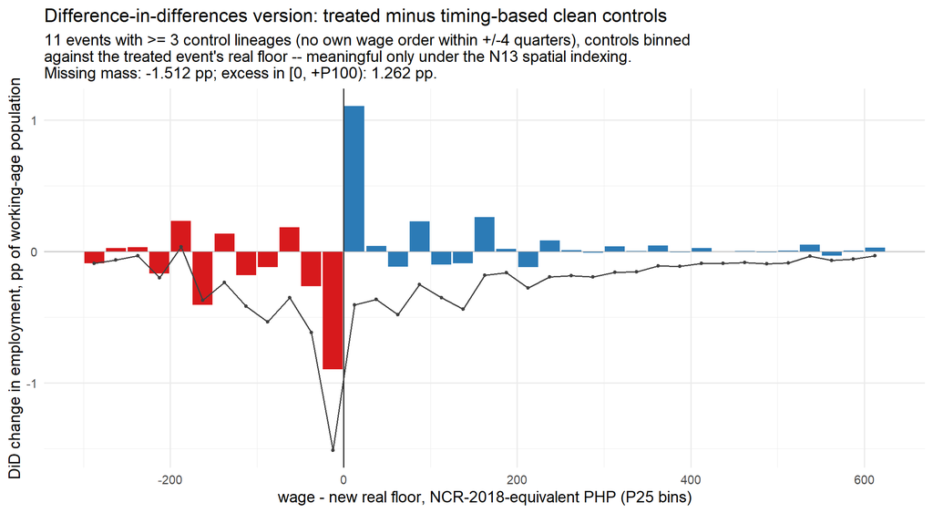

```r
# DiD version: treated Delta E minus timing-based clean-control Delta E,
# events with >= MIN_CONTROLS controls, same averaging and display.
did_ids <- events %>% filter(did_ok) %>% pull(event_id)

evt_did_head <- evt_did %>%
  filter(event_id %in% did_ids, tau >= 0, tau <= 3) %>%
  group_by(event_id, bin) %>%
  summarise(dE_post = mean(dE_did), .groups = "drop") %>%
  group_by(bin) %>%
  summarise(dE = 100 * mean(dE_post), .groups = "drop") %>%
  arrange(bin) %>%
  mutate(cum_dE = cumsum(dE))

miss_did <- sum(evt_did_head$dE[evt_did_head$bin < 0])
xs_did   <- sum(evt_did_head$dE[evt_did_head$bin >= 0 & evt_did_head$bin < 100])

ggplot(evt_did_head, aes(bin + BIN_PHP / 2)) +
  geom_col(aes(y = dE, fill = bin < 0), width = BIN_PHP * 0.92,
           show.legend = FALSE) +
  geom_line(aes(y = cum_dE), colour = "grey25", linewidth = 0.6) +
  geom_point(aes(y = cum_dE), colour = "grey25", size = 0.9) +
  geom_vline(xintercept = 0, colour = "grey20", linewidth = 0.5) +
  geom_hline(yintercept = 0, colour = "grey60", linewidth = 0.3) +
  scale_fill_manual(values = c(`TRUE` = "#d7191c", `FALSE` = "#2c7bb6")) +
  labs(title = "Difference-in-differences version: treated minus timing-based clean controls",
       subtitle = wrap_text(sprintf(
         "%d events with >= %d control lineages (no own wage order within +/-4 quarters), controls binned against the treated event's real floor -- meaningful only under the N13 spatial indexing. Missing mass: %.3f pp; excess in [0, +P100): %.3f pp.",
         length(did_ids), MIN_CONTROLS, miss_did, xs_did)),
       x = "wage - new real floor, NCR-2018-equivalent PHP (P25 bins)",
       y = "DiD change in employment, pp of working-age population")
```

**Reading.** Netting out control lineages sharpens the trough-and-spike at the floor and enlarges both masses, but the interpretation below applies with force here: this rests on few events, drawn from freeze-adjacent episodes, and the placebo bins do not sit cleanly at zero — so read the shape as better-adjusted description of reallocation around the floor, not as a causal employment estimate.

```r
# Summary table with the PoC's B* grid, the Cengiz headline %-effect, and
# bootstrap CIs over events.
# Per event: Delta_b = sum_{b<0} dE; Delta_a(B*) = sum_{0<=b<B*} dE;
# net(B*) = Delta_b + Delta_a(B*); placebo = sum_{300<=b<600} dE;
# pre_below = pre-window per-capita mass below the new floor (the "affected
# employment" denominator). Headline %-effect (Cengiz):
#     pct_net = 100 * mean(net_100) / mean(pre_below)
# = percent change in affected (below-new-floor) employment. CIs: percentile
# bootstrap resampling EVENTS (N_BOOT draws); the % effect is bootstrapped
# jointly (ratio of resampled means).
event_level <- function(dE_tbl, val_col) {
  dE_tbl %>%
    group_by(event_id) %>%
    summarise(
      d_below   = 100 * sum(.data[[val_col]][bin < 0]),
      d_a100    = 100 * sum(.data[[val_col]][bin >= 0 & bin < 100]),
      d_a200    = 100 * sum(.data[[val_col]][bin >= 0 & bin < 200]),
      d_a300    = 100 * sum(.data[[val_col]][bin >= 0 & bin < 300]),
      d_placebo = 100 * sum(.data[[val_col]][bin >= PLACEBO_LO]),
      .groups = "drop")
}

# Pre-window affected mass (treated units), per event
pre_mass <- evt_dE %>%
  filter(role == "treat") %>%
  distinct(event_id, bin, E_pre) %>%
  group_by(event_id) %>%
  summarise(pre_below = 100 * sum(E_pre[bin < 0]), .groups = "drop")

ev_raw <- evt_dE %>%
  filter(role == "treat", event_id %in% headline_ids, tau >= 0, tau <= 3) %>%
  group_by(event_id, bin) %>% summarise(v = mean(dE), .groups = "drop") %>%
  event_level("v") %>% left_join(pre_mass, by = "event_id")
ev_did <- evt_did %>%
  filter(event_id %in% did_ids, tau >= 0, tau <= 3) %>%
  group_by(event_id, bin) %>% summarise(v = mean(dE_did), .groups = "drop") %>%
  event_level("v") %>% left_join(pre_mass, by = "event_id")

boot_ci <- function(x) {
  bs <- replicate(N_BOOT, mean(sample(x, replace = TRUE)))
  sprintf("[%.3f, %.3f]", quantile(bs, 0.025), quantile(bs, 0.975))
}
boot_ci_ratio <- function(num, den) {   # CI for 100*mean(num)/mean(den)
  n <- length(num)
  bs <- replicate(N_BOOT, { i <- sample.int(n, replace = TRUE)
                            100 * mean(num[i]) / mean(den[i]) })
  sprintf("[%.1f, %.1f]", quantile(bs, 0.025), quantile(bs, 0.975))
}
summarise_est <- function(ev, label) {
  net <- ev$d_below + ev$d_a100
  tibble(
    estimator      = label,
    n_events       = nrow(ev),
    pre_below      = mean(ev$pre_below),
    delta_below    = mean(ev$d_below),
    ci_below       = boot_ci(ev$d_below),
    delta_a100     = mean(ev$d_a100),
    ci_a100        = boot_ci(ev$d_a100),
    net_100        = mean(net),
    ci_net100      = boot_ci(net),
    pct_effect     = 100 * mean(net) / mean(ev$pre_below),
    ci_pct         = boot_ci_ratio(net, ev$pre_below),
    delta_a200     = mean(ev$d_a200),
    delta_a300     = mean(ev$d_a300),
    bunch_ratio    = mean(ev$d_a100) / abs(mean(ev$d_below)),
    placebo_300up  = mean(ev$d_placebo),
    ci_placebo     = boot_ci(ev$d_placebo)
  )
}
evt_summary <- bind_rows(summarise_est(ev_raw, "Raw stacked (pre/post)"),
                         summarise_est(ev_did, "DiD vs timing controls"))
evt_summary %>%
  kt("Cengiz-style summary, pp of working-age population unless noted: pre-window affected mass below the new floor; missing mass; excess mass (B* = P100, with P200/P300 in later columns); net low-wage change; pct_effect = 100 x net / pre-affected mass (the Cengiz headline '% change in affected employment'); bunching ratio; upper-tail placebo [P300, P600). Brackets: 95% percentile bootstrap over events.",
     digits = 3)
```

Cengiz-style summary, pp of working-age population unless noted: pre-window affected mass below the new floor; missing mass; excess mass (B* = P100, with P200/P300 in later columns); net low-wage change; pct_effect = 100 x net / pre-affected mass (the Cengiz headline ‘% change in affected employment’); bunching ratio; upper-tail placebo [P300, P600). Brackets: 95% percentile bootstrap over events.

| estimator | n_events | pre_below | delta_below | ci_below | delta_a100 | ci_a100 | net_100 | ci_net100 | pct_effect | ci_pct | delta_a200 | delta_a300 | bunch_ratio | placebo_300up | ci_placebo |
| --- | --- | --- | --- | --- | --- | --- | --- | --- | --- | --- | --- | --- | --- | --- | --- |
| Raw stacked (pre/post) | 158 | 9.454 | -0.268 | [-0.492, -0.066] | 0.432 | [0.225, 0.614] | 0.164 | [-0.016, 0.333] | 1.735 | [-0.1, 3.5] | 0.462 | 0.487 | 1.612 | 0.039 | [0.008, 0.066] |
| DiD vs timing controls | 11 | 11.308 | -1.512 | [-3.503, 0.205] | 1.262 | [0.054, 2.942] | -0.250 | [-0.856, 0.201] | -2.213 | [-7.0, 1.7] | 1.352 | 1.318 | 0.834 | 0.163 | [0.077, 0.268] |

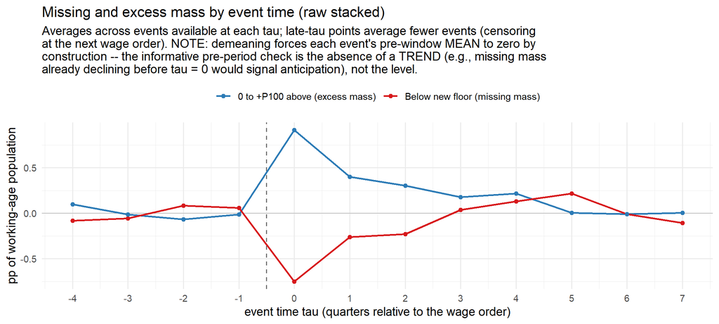

```r
# Time path (raw): Delta-b and Delta-a(100) by event time, averaged over
# events available at each tau (post censoring changes composition).
tau_path <- evt_dE %>%
  filter(role == "treat") %>%
  group_by(event_id, tau) %>%
  summarise(d_below  = 100 * sum(dE[bin < 0]),
            d_excess = 100 * sum(dE[bin >= 0 & bin < 100]), .groups = "drop") %>%
  group_by(tau) %>%
  summarise(n_events = n(),
            `Below new floor (missing mass)` = mean(d_below),
            `0 to +P100 above (excess mass)` = mean(d_excess), .groups = "drop")

tau_path %>%
  pivot_longer(-c(tau, n_events)) %>%
  ggplot(aes(tau, value, colour = name)) +
  geom_hline(yintercept = 0, colour = "grey60", linewidth = 0.3) +
  geom_vline(xintercept = -0.5, linetype = "dashed", colour = "grey40") +
  geom_line(linewidth = 0.8) + geom_point(size = 1.6) +
  scale_colour_manual(values = c("#2c7bb6", "#d7191c")) +
  scale_x_continuous(breaks = -EVENT_PRE_Q:EVENT_POST_Q) +
  labs(title = "Missing and excess mass by event time (raw stacked)",
       subtitle = wrap_text("Averages across events available at each tau; late-tau points average fewer events (censoring at the next wage order). NOTE: demeaning forces each event's pre-window MEAN to zero by construction -- the informative pre-period check is the absence of a TREND (e.g., missing mass already declining before tau = 0 would signal anticipation), not the level."),
       x = "event time tau (quarters relative to the wage order)",
       y = "pp of working-age population", colour = NULL) +
  theme(legend.position = "top")
```

**Reading.** The dynamics carry the distinctive Philippine finding: both masses jump at τ = 0, then decay toward zero within roughly four to five quarters as inflation and wage growth carry the distribution past the fixed real event-floor — each order’s bite is transient, and the near-annual cadence restarts the cycle. The flat pre-period is consistent with limited anticipation, remembering that only a pre-*trend*, not the pre-level, is informative here.

## 14.2 Interpreting the Estimates

The template below is written against the objects just computed, so the sentences update automatically when the document is knit on different data or parameters.

**Raw stacked (158 events).** In the first year under a new wage order, employment below the new real floor changes by **-0.268 pp of working-age population** (95% CI [-0.492, -0.066]) against a pre-window affected mass of 9.454 pp, while employment in the first ₱100 at/above the floor changes by **0.432 pp** ([0.225, 0.614]). The net low-wage change is **0.164 pp** ([-0.016, 0.333]), i.e. **1.7%** of pre-order affected employment ([-0.1, 3.5]). A bunching ratio of 1.61 says each percentage point leaving the sub-floor region is matched by 1.61 pp appearing just above it. The upper-tail placebo is 0.039 pp ([0.008, 0.066]): values away from zero mean the raw contrast is also picking up distribution-wide drift (secular real wage growth across the fixed real ruler), so raw magnitudes should not be read as floor-caused.

**DiD vs timing controls (11 events).** Netting out contemporaneous changes in control lineages, the below-floor change is **-1.512 pp** ([-3.503, 0.205]) and the excess in [0, ₱100) is **1.262 pp** ([0.054, 2.942]); the net effect is **-0.250 pp** ([-0.856, 0.201]), or **-2.2%** of affected employment ([-7.0, 1.7]). Read the three CIs together: if the missing- and excess-mass CIs exclude zero while the net CI includes it, the data show clear *reallocation* across the floor with no detectable *employment* effect – the Cengiz pattern. A DiD placebo of 0.163 pp ([0.077, 0.268]) materially different from zero is a warning that treated-vs-control differences are not confined to the floor region, so part of the measured masses reflects broader relative-distribution shifts (see Threats, especially control selection), and the DiD should be read as better-adjusted description rather than a causal estimate.

The event-time chart adds the dynamics: in the Philippine setting the excess mass typically decays over $\tau = 1 \dots 5$ and the missing mass climbs back toward zero — the fixed real event-floor stops binding as inflation and wage growth carry the distribution past it, and the next annual order restarts the cycle. That decay profile is itself a finding: the bite of any single order is transient by construction of the near-annual wage-setting cadence.

## 14.3 Threats to Validity

Ordered roughly from mechanical to fundamental:

1. **Repeated cross-sections, not workers.** Bin masses track *positions in the distribution*, not persons. “Missing mass” cannot distinguish a worker raised to the floor from one who lost a job while another was hired above it. Composition shifts (formalization, sectoral change, survey redesigns in 2021) move bin masses without any wage-order cause.
2. **Measurement at the floor.** Digit heaping (heaping diagnostics), basic-vs-total pay mismatch (COLA), and the min–max rate interval all blur exactly the bins the design cares about. A worker lawfully paid `total_min` sits “below the floor” when the ruler is `total_max`.
3. **Bin-range truncation.** Mass below −₱300 or above +₱600 (NCR-2018 equivalent) is outside the ledger; the out-of-range share is reported above and tracked per event in the sanity exports.
4. **Anticipation.** Orders are petitioned, deliberated, and published before effectivity; employers can adjust at $\tau = -1$. The as-of anchor also delays mid-quarter orders to the next round, smearing $\tau = 0$. Both bias the pre-window toward containing treatment.
5. **Endogenous treatment timing.** Boards raise floors when regional labor markets can bear it; raw post-minus-pre contrasts therefore load expansion-phase wage growth into “effects.” This is visible in the raw upper-tail placebo.
6. **Endogenous control selection — the deepest problem for the DiD.** Control lineages exist mainly because their boards froze, and freezes cluster in crises (2009–10, 2020–21). The DiD therefore compares boards that raised *during* stress episodes with boards that chose not to — both choices reflecting regional conditions. Parallel trends is a strong assumption exactly where the design needs it; a nonzero DiD placebo is the visible symptom.
7. **Spillovers across “control” borders (SUTVA).** Commuting and migration link adjacent regions (NCR–CALABARZON above all); a treated region’s order can move a control region’s wages, contaminating the counterfactual in either direction.
8. **Censoring-induced composition across $\tau$.** Later event-time points average fewer, longer-gap events (freeze-adjacent by construction), so the $\tau$-profile mixes dynamics with composition.
9. **Few DiD events.** The clean-control screen leaves a small, non-random subset of events (`MIN_CONTROLS` is a parameter; loosening it trades subset size against control quality). Bootstrap CIs are wide, and they resample events only — survey design (PSU/stratum) uncertainty is not propagated.
10. **The common scale is model-dependent.** Everything runs through N13: regional CPIs for time, a fixed 2018 poverty-basket ratio for place. Errors in either deflator translate real wages across bin boundaries mechanically, and $\theta_r$ is a low-income basket held at 2018 relatives.

## 14.4 Hidden Validation Exports

A non-rendering validation chunk at the end of the document writes machine-checkable diagnostics to `Output/sanity_checks_summary.csv`, `Output/sanity_event_registry.csv`, `Output/sanity_bin_reconciliation.csv`, and `Output/sanity_mw_assignment_sample.csv` – internal identities, reconciliations, and per-event audit rows that would clutter this HTML. They are meant to be inspected (or shared) as flat files.

# 15 Lower-Tail Compression

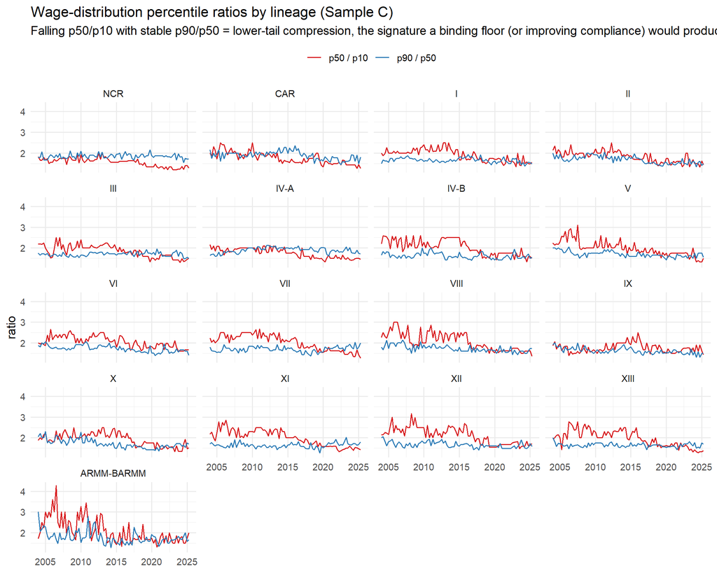

```r
# Percentile ratios from bind_qtr: p50/p10 (lower tail) and p90/p50 (upper).
bind_qtr %>%
  mutate(`p50 / p10` = p50 / p10, `p90 / p50` = p90 / p50) %>%
  select(region_wb, ref_date, `p50 / p10`, `p90 / p50`) %>%
  pivot_longer(-c(region_wb, ref_date)) %>%
  ggplot(aes(ref_date, value, colour = name)) +
  geom_line(linewidth = 0.5) +
  facet_wrap(~region_wb, ncol = 4) +
  scale_colour_manual(values = c("p50 / p10" = "#d7191c", "p90 / p50" = "#2c7bb6")) +
  labs(title = "Wage-distribution percentile ratios by lineage (Sample C)",
       subtitle = "Falling p50/p10 with stable p90/p50 = lower-tail compression, the signature a binding floor (or improving compliance) would produce.",
       x = NULL, y = "ratio", colour = NULL) +
  theme(legend.position = "top")
```

**Reading.** The lower-tail ratio p50/p10 and the upper-tail ratio p90/p50 answer different questions: a floor that binds should compress the former and leave the latter alone. Panels where p50/p10 hugs a low, flat line are regions where the floor (plus whatever else compresses bottoms) leaves little room between the median and the 10th percentile. Compression is *consistent with* a binding floor but equally consistent with compressed productivity distributions; this chart cannot separate them.

# 16 Reconciliation with the NCR Proof of Concept

The NCR PoC’s published numbers used different conventions (its sample included Government/GOCC and Private Household, imposed no industry restriction, and measured the at-band in real ±₱25). This section recomputes NCR under **both** convention sets on the same underlying data, so any difference between this document’s NCR facet and the PoC is attributable to conventions, not to data or code drift.

```r
# PoC conventions: classes {PE, Gov, PH}, all industries, threshold total_max,
# at-band |real w - real MW| <= 25 (2018 PHP).
# New conventions: Sample C, +/-5% band. Both at Q2 of selected years.
recon_years <- c(2004, 2009, 2014, 2019, 2024)

ncr_poc <- sample_B %>%
  filter(region_wb == "NCR", quarter == 2, year %in% recon_years) %>%
  mutate(real_pay = basic_pay_php / defl, real_mw = mw_tot_max / defl) %>%
  group_by(year) %>%
  summarise(convention = "PoC (B-sample, all industries, real +/-P25)",
            kaitz_med  = first(mw_tot_max) / weighted_quantile(basic_pay_php, weight, 0.5),
            F_at_below = wshare(basic_pay_php <= mw_tot_max, weight),
            B_strict   = wshare(basic_pay_php <  mw_tot_max, weight),
            at_band    = wshare(abs(real_pay - real_mw) <= AT_MW_BAND_PHP_REAL, weight),
            .groups = "drop")

ncr_new <- sample_C %>%
  filter(region_wb == "NCR", quarter == 2, year %in% recon_years) %>%
  group_by(year) %>%
  summarise(convention = "This doc (C-sample, non-agri PE, +/-5%)",
            kaitz_med  = first(mw_tot_max) / weighted_quantile(basic_pay_php, weight, 0.5),
            F_at_below = wshare(basic_pay_php <= mw_tot_max, weight),
            B_strict   = wshare(basic_pay_php <  mw_tot_max, weight),
            at_band    = wshare(abs(basic_pay_php / mw_tot_max - 1) <= AT_MW_BAND_PCT, weight),
            .groups = "drop")

bind_rows(ncr_poc, ncr_new) %>%
  arrange(year, convention) %>%
  kt("NCR at Q2 of selected years under PoC vs. this document's conventions. Differences between the rows of each year-pair are convention effects (sample composition and band definition), computed on identical underlying data.",
     digits = 3)
```

NCR at Q2 of selected years under PoC vs. this document’s conventions. Differences between the rows of each year-pair are convention effects (sample composition and band definition), computed on identical underlying data.

| year | convention | kaitz_med | F_at_below | B_strict | at_band |
| --- | --- | --- | --- | --- | --- |
| 2004 | PoC (B-sample, all industries, real +/-P25) | 1.000 | 0.545 | 0.398 | 0.217 |
| 2004 | This doc (C-sample, non-agri PE, +/-5%) | 1.000 | 0.522 | 0.344 | 0.253 |
| 2009 | PoC (B-sample, all industries, real +/-P25) | 1.000 | 0.583 | 0.466 | 0.282 |
| 2009 | This doc (C-sample, non-agri PE, +/-5%) | 1.000 | 0.549 | 0.405 | 0.336 |
| 2014 | PoC (B-sample, all industries, real +/-P25) | 1.022 | 0.619 | 0.542 | 0.234 |
| 2014 | This doc (C-sample, non-agri PE, +/-5%) | 1.002 | 0.593 | 0.500 | 0.270 |
| 2019 | PoC (B-sample, all industries, real +/-P25) | 1.000 | 0.556 | 0.313 | 0.319 |
| 2019 | This doc (C-sample, non-agri PE, +/-5%) | 1.000 | 0.543 | 0.272 | 0.354 |
| 2024 | PoC (B-sample, all industries, real +/-P25) | 0.897 | 0.458 | 0.205 | 0.308 |
| 2024 | This doc (C-sample, non-agri PE, +/-5%) | 0.871 | 0.445 | 0.163 | 0.338 |

# 17 Robustness

## 17.1 Total vs. basic rates

LFS basic pay may exclude COLA-type allowances that the `total_*` rates include; comparing it to `basic_max` is the concept-matched alternative. The gap between the two series bounds the COLA-mismatch effect on measured noncompliance.

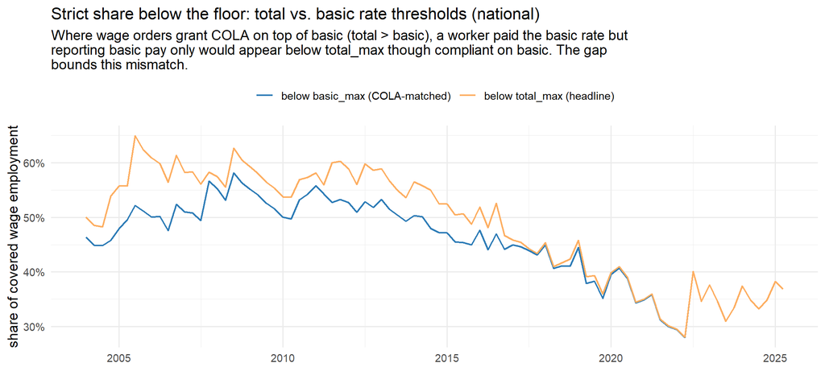

```r
bind_nat %>%
  select(ref_date, `below total_max (headline)` = B_max,
         `below basic_max (COLA-matched)` = B_bas_max) %>%
  pivot_longer(-ref_date) %>%
  ggplot(aes(ref_date, value, colour = name)) +
  geom_line(linewidth = 0.7, na.rm = TRUE) +
  scale_y_continuous(labels = percent_format()) +
  scale_colour_manual(values = c("#2c7bb6", "#fdae61")) +
  labs(title = "Strict share below the floor: total vs. basic rate thresholds (national)",
       subtitle = wrap_text("Where wage orders grant COLA on top of basic (total > basic), a worker paid the basic rate but reporting basic pay only would appear below total_max though compliant on basic. The gap bounds this mismatch."),
       x = NULL, y = "share of covered wage employment", colour = NULL) +
  theme(legend.position = "top")
```

## 17.2 Band definitions

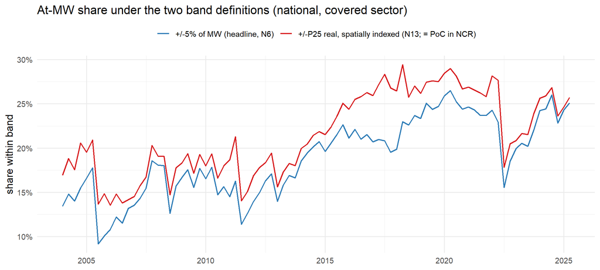

```r
bind_nat %>%
  select(ref_date, `+/-5% of MW (headline, N6)` = part_at,
         `+/-P25 real, spatially indexed (N13; = PoC in NCR)` = at_real25s) %>%
  pivot_longer(-ref_date) %>%
  ggplot(aes(ref_date, value, colour = name)) +
  geom_line(linewidth = 0.7) +
  scale_y_continuous(labels = percent_format()) +
  scale_colour_manual(values = c("#2c7bb6", "#d7191c")) +
  labs(title = "At-MW share under the two band definitions (national, covered sector)",
       x = NULL, y = "share within band", colour = NULL) +
  theme(legend.position = "top")
```

## 17.3 Weighted vs. unweighted

```r
sample_C %>%
  filter(year == max(year[quarter <= 2])) %>%
  group_by(region_wb) %>%
  summarise(B_weighted   = wshare(basic_pay_php < mw_tot_max, weight),
            B_unweighted = mean(basic_pay_php < mw_tot_max),
            .groups = "drop") %>%
  kt("Strict below-MW share, weighted vs unweighted, latest year, by lineage. Gaps reflect the design's oversampling of smaller domains.", digits = 3)
```

Strict below-MW share, weighted vs unweighted, latest year, by lineage. Gaps reflect the design’s oversampling of smaller domains.

| region_wb | B_weighted | B_unweighted |
| --- | --- | --- |
| NCR | 0.176 | 0.185 |
| CAR | 0.199 | 0.227 |
| I | 0.471 | 0.457 |
| II | 0.419 | 0.367 |
| III | 0.379 | 0.376 |
| IV-A | 0.417 | 0.446 |
| IV-B | 0.477 | 0.467 |
| V | 0.224 | 0.234 |
| VI | 0.565 | 0.527 |
| VII | 0.391 | 0.309 |
| VIII | 0.543 | 0.532 |
| IX | 0.566 | 0.540 |
| X | 0.463 | 0.455 |
| XI | 0.468 | 0.535 |
| XII | 0.499 | 0.477 |
| XIII | 0.385 | 0.362 |
| ARMM-BARMM | 0.587 | 0.562 |

# 18 Validation Exports (Non-Rendering)

This chunk renders nothing. It recomputes internal identities and writes them, plus per-event and per-cell audit rows, to `Output/sanity_*.csv` for machine checking outside the HTML.

# 19 Limitations and Caveats Register

Collected here so no chart has to carry every footnote:

1. **Coverage vs. noncompliance.** The LFS cannot observe establishment size (retail/service < 10 workers exemptions), apprentice/learner status, or BMBE registration. “Below MW” therefore includes some workers lawfully paid under special rates; the N5 interval bounds only the *multi-rate* ambiguity, not these exemptions.
2. **Basic pay vs. total compensation.** `basic_pay_php` excludes overtime, most allowances, 13th-month pay, and tips (correct for testing the statutory floor on basic pay, but not take-home pay). The total-vs-basic robustness chart bounds the COLA side of this.
3. **One rate per lineage.** Sub-regional (provincial / area-class) rate differentiation is collapsed to the [total_min, total_max] interval; LFS geography cannot do better (province missing 2019 Q1–2021 Q1, place-of-work-based from 2021 Q2).
4. **NIR seams.** NIR observations (2016 Q4, 2025+) are mapped to VI/VII by province; rows with missing province are dropped (counted in the recode validation). The 2023 poverty-threshold vintage excludes Negros from VI/VII while the lineages include it.
5. **Region VIII, 2013 Q4–2015 Q2.** Yolanda disrupted enumeration (absent 2014 Q1, reduced samples after); Region VIII series there describe a non-comparable population.
6. **Mid-quarter wage orders.** The N2 anchor (first of the reference month) assigns an order effective later in the quarter to the *next* round; a last-day anchor would shift some assignments by one quarter.
7. **Heaping.** The heaping diagnostics’ shares quantify round-number reporting; ±5%-band and at-MW statistics partly reflect it. The off-round split is the cleaner evidence; no fixed heaping level “validates” bunching.
8. **Survey redesigns.** The 2021 sample expansion and weight rebasings (visible in the coverage grid and doc-1’s population series) change precision, not concepts; no adjustment is applied.
9. **No standard errors.** All statistics are weighted point estimates. Inference requires `survey::svydesign(ids = ~psu, strata = ~stratum, nest = TRUE)`; planned for the causal follow-up, not this descriptive document.
10. **Event study is close-to-Cengiz, not Cengiz.** Timing-based controls (no own wage order within ±4 quarters) are selected on wage-order timing, not random assignment; control availability clusters in freeze episodes (2009–10, 2020–21), so the DiD subset is not a random draw of events. Raw pre/post estimates absorb macro shocks entirely. Pre-period profiles and the upper-tail placebo are the internal checks; bootstrap CIs resample events, not survey PSUs.
11. **The spatial index is a poverty-basket index.** $\theta_r$ deflates cross-region price levels with the 2018 poverty-threshold basket, which is a low-income consumption basket — the right basket for wage floors near the poverty line, but not a general spatial PPP. It is also held fixed at 2018 relatives; regional relative price-level drift over 2004–2025 is absorbed by the CPI only to the extent regional CPIs capture it.
12. **CHECK-flagged wage-order rows.** Six source rows with effectivity preceding issuance are used as-is (validation table), per the doc-1 convention.